# grupo2-trabalho1

Unidade Curricular : Métodos Estatísticos

Primeiro de tudo correr as funções que vão utilizar para o programa.

```r
# moda
moda <- function(x)
{
   ux <- unique(x)
   tab <- tabulate(match(x, ux))
   ux[tab == max(tab)]
}

# formula sturges
sturges <- function(x)
{
  floor((1 + log(length(x)) / log(2)))
}

# amplitude sturges
amplitude <- function(x)
{
  max <- max(x)
  min <- min(x)
  nclass <- sturges(x)
  (max - min) / nclass
}

# coeficiente de variacao
coeficiente_variacao <- function(x)
{
  s <- sd(x)
  m <- mean(x)
  s/m * 100
}

# funcao de assimetria
assimetria <- function(x)
{
  n <-length(x)
  s <- sd(x)
  m <- mean(x)
  1/n * sum((x - m)^3/s^3)
}

# funcao de achatamento ou curtose
achatamento <- function(x)
{
  n <- length(x)
  s <- sd(x)
  m <- mean(x)
  1/n * sum((x - m)^4/s^4) - 3
}

# funcao de oulier quantiles
outliers_quantiles <- function(x, o)
{
  sx <- sort(x)
  n <- length(x)
  nps <- c(round(n * .25), round(n * .50), round(n * .75))
  qs <- c(sx[nps[1]],sx[nps[2]], sx[nps[3]])
}

# funcao de outlier moderado
outlier_moderado <- function(x, o)
{
  result <- FALSE
  oqs <- outliers_quantiles(x, o)
  om <- c(oqs[1] - 1.5 * (oqs[3] - oqs[1]), oqs[1] - 3 * (oqs[3] - oqs[1]), oqs[3] + 1.5 * (oqs[3] - oqs[1]) , oqs[3] + 3 *  (oqs[3] - oqs[1]))
  result <- ((o >= om[1] && o <= om[2]) || (o >= om[3] && o <= om[4]))
  result
}

# funcao de oulier severo
outlier_severo <- function(x, o)
{
  result <- FALSE
  oqs <- outliers_quantiles(x, o)
  os <- c(oqs[1] - 3 * (oqs[3] - oqs[1]), oqs[3] + 3 *  (oqs[3] - oqs[1]))
  result <- (o < os[1]) || (o > os[2])
  result
}

# funcao de outliers tipo moderado
outliers_type_moderado <- function(x, os)
{
  result <- c()
  if(!is.na(os[1]))
  {
    for(i in 1:length(os))
    {
      m <- outlier_moderado(x, os[i])
      if (m)
      {
        result <- c(result, os[i])
      }
    }
  }
  result
}

# funcao de outliers tipo severo
outliers_type_severo <- function(x, os)
{
  result <- c()
  if(!is.na(os[1]))
  {
    for(i in 1:length(os))
    {
      s <- outlier_severo(x, os[i])
      if (s)
      {
        result <- c(result, os[i])
      }
    }
  }
  result
}
```

```r
# importar dataset
# alterar caminho para o vosso
# importar dataset
hour.dataset <- "D:/LEI/matematica/Metodos_Estatisticos/2122/ME_Trabalhos_2122/hour.csv"

# Todos os alugueres todas as horas
hour <- read.csv(file = hour.dataset)

# Todos os alugueres entre as 7 às 18
hour.day <- subset(hour, 6<hr & hr<19)

# Todos os alugueres entre as 19 às 6
hour.night <- subset(hour, hr>18 | hr<7)

# Ver tabelas importadas no RStudio
View(hour)
```

```r
# tabela frequencia
local({
  .Table <- with(hour, table(hr))
  cat("\ncounts:\n")
  print(.Table)
  cat("\npercentages:\n")
  print(round(100*.Table/sum(.Table), 2))
})
```

```
##
## counts:
## hr
##   0   1   2   3   4   5   6   7   8   9  10  11  12  13  14  15  16  17  18  19
## 726 724 715 697 697 717 725 727 727 727 727 727 728 729 729 729 730 730 728 728
##  20  21  22  23
## 728 728 728 728
##
## percentages:
## hr
##    0    1    2    3    4    5    6    7    8    9   10   11   12   13   14   15
## 4.18 4.17 4.11 4.01 4.01 4.13 4.17 4.18 4.18 4.18 4.18 4.18 4.19 4.19 4.19 4.19
##   16   17   18   19   20   21   22   23
## 4.20 4.20 4.19 4.19 4.19 4.19 4.19 4.19
```

```r
# quartis
summary(hour)
```

```
##     instant         dteday              season            yr
##  Min.   :    1   Length:17379       Min.   :1.000   Min.   :0.0000
##  1st Qu.: 4346   Class :character   1st Qu.:2.000   1st Qu.:0.0000
##  Median : 8690   Mode  :character   Median :3.000   Median :1.0000
##  Mean   : 8690                      Mean   :2.502   Mean   :0.5026
##  3rd Qu.:13034                      3rd Qu.:3.000   3rd Qu.:1.0000
##  Max.   :17379                      Max.   :4.000   Max.   :1.0000
##       mnth              hr           holiday           weekday
##  Min.   : 1.000   Min.   : 0.00   Min.   :0.00000   Min.   :0.000
##  1st Qu.: 4.000   1st Qu.: 6.00   1st Qu.:0.00000   1st Qu.:1.000
##  Median : 7.000   Median :12.00   Median :0.00000   Median :3.000
##  Mean   : 6.538   Mean   :11.55   Mean   :0.02877   Mean   :3.004
##  3rd Qu.:10.000   3rd Qu.:18.00   3rd Qu.:0.00000   3rd Qu.:5.000
##  Max.   :12.000   Max.   :23.00   Max.   :1.00000   Max.   :6.000
##    workingday       weathersit         temp           atemp
##  Min.   :0.0000   Min.   :1.000   Min.   :0.020   Min.   :0.0000
##  1st Qu.:0.0000   1st Qu.:1.000   1st Qu.:0.340   1st Qu.:0.3333
##  Median :1.0000   Median :1.000   Median :0.500   Median :0.4848
##  Mean   :0.6827   Mean   :1.425   Mean   :0.497   Mean   :0.4758
##  3rd Qu.:1.0000   3rd Qu.:2.000   3rd Qu.:0.660   3rd Qu.:0.6212
##  Max.   :1.0000   Max.   :4.000   Max.   :1.000   Max.   :1.0000
##       hum           windspeed          casual         registered
##  Min.   :0.0000   Min.   :0.0000   Min.   :  0.00   Min.   :  0.0
##  1st Qu.:0.4800   1st Qu.:0.1045   1st Qu.:  4.00   1st Qu.: 34.0
##  Median :0.6300   Median :0.1940   Median : 17.00   Median :115.0
##  Mean   :0.6272   Mean   :0.1901   Mean   : 35.68   Mean   :153.8
##  3rd Qu.:0.7800   3rd Qu.:0.2537   3rd Qu.: 48.00   3rd Qu.:220.0
##  Max.   :1.0000   Max.   :0.8507   Max.   :367.00   Max.   :886.0
##       cnt
##  Min.   :  1.0
##  1st Qu.: 40.0
##  Median :142.0
##  Mean   :189.5
##  3rd Qu.:281.0
##  Max.   :977.0
```

## **1. temp**

### Medidas de Tendência Central

```r
# Contagem de valores
table(hour$temp)
```

```
##
## 0.02 0.04 0.06 0.08  0.1 0.12 0.14 0.16 0.18  0.2 0.22 0.24 0.26 0.28  0.3 0.32
##   17   16   16   17   51   76  138  230  155  354  421  522  559  301  641  611
## 0.34 0.36 0.38  0.4 0.42 0.44 0.46 0.48  0.5 0.52 0.54 0.56 0.58  0.6 0.62 0.64
##  645  671  372  614  548  507  559  288  531  556  569  579  305  675  726  692
## 0.66 0.68  0.7 0.72 0.74 0.76 0.78  0.8 0.82 0.84 0.86 0.88  0.9 0.92 0.94 0.96
##  693  349  690  570  516  396  169  325  213  138  131   53   90   49   17   16
## 0.98    1
##    1    1
```

#### Moda

```r
hour.temp.sort <- sort(hour$temp)

hour.temp.mode <- moda(hour.temp.sort)
hour.temp.mode
```

```
## [1] 0.62
```

#### Média

```r
hour.temperatura.media <- mean(hour$temp)
hour.temperatura.media
```

```
## [1] 0.4969872
```

#### Mediana

```r
hour.temperatura.mediana <- median(hour$temp)
hour.temperatura.mediana
```

```
## [1] 0.5
```

#### Quartil

```r
hour.temperatura.quantile <- quantile(hour$temp)
hour.temperatura.quantile
```

```
##   0%  25%  50%  75% 100%
## 0.02 0.34 0.50 0.66 1.00
```

### Medidas de Dispersão Central

#### Variância

```r
hour.temperatura.variancia <- var(hour$temp)
hour.temperatura.variancia
```

```
## [1] 0.03707786
```

#### Desvio Padrão

```r
hour.temperatura.desvio_padrao <- sd(hour$temp)
hour.temperatura.desvio_padrao
```

```
## [1] 0.1925561
```

#### Coeficiente de Variação

```r
hour.temperatura.coeficiente_variacao <- coeficiente_variacao(hour$temp)
hour.temperatura.coeficiente_variacao
```

```
## [1] 38.74469
```

### Valores Extremos

#### Máximo

```r
hour.temperatura.maxima <- max(hour$temp)
hour.temperatura.maxima
```

```
## [1] 1
```

#### Mínimo

```r
hour.temperatura.minima <- min(hour$temp)
hour.temperatura.minima
```

```
## [1] 0.02
```

### Medidas de Assimetria

```r
hour.temperatura.assimetria <- assimetria(hour$temp)
hour.temperatura.assimetria
```

```
## [1] -0.006019844
```

De acordo com o resultado, é assimétrica negativa fraca (ou enviesada para a esquerda).

### Medidas de Curtose ou Achatamento

```r
hour.temperatura.achatamento <- achatamento(hour$temp)
hour.temperatura.achatamento
```

```
## [1] -0.9421553
```

Curva platicúrtica, achatada, o que significa que os valores estão pouco concentrados em torno da média e, consequentemente, existe uma variação elevada.

### Histograma

```r
# formula de sturges
cat("Número de classes\n")
```

```
## Número de classes
```

```r
hour.temp.sturges.nclass <- sturges(hour$temp)
hour.temp.sturges.nclass
```

```
## [1] 15
```

```r
# amplitude da classe
cat("\nAmplitude da classe\n")
```

```
##
## Amplitude da classe
```

```r
hour.temp.sturges.amplitude <- amplitude(hour$temp)
hour.temp.sturges.amplitude
```

```
## [1] 0.06533333
```

```r
# tabela de frequencias
cat("\nClasses\n")
```

```
##
## Classes
```

```r
hour.temp.sturges.breaks <- seq(hour.temperatura.minima, hour.temperatura.maxima, hour.temp.sturges.amplitude)
hour.temp.sturges.breaks
```

```
##  [1] 0.02000000 0.08533333 0.15066667 0.21600000 0.28133333 0.34666667
##  [7] 0.41200000 0.47733333 0.54266667 0.60800000 0.67333333 0.73866667
## [13] 0.80400000 0.86933333 0.93466667 1.00000000
```

```r
cat("\nTabela de frequências\n")
```

```
##
## Tabela de frequências
```

```r
table(cut(hour$temp, breaks=hour.temp.sturges.breaks))
```

```
##
##  (0.02,0.0853] (0.0853,0.151]  (0.151,0.216]  (0.216,0.281]  (0.281,0.347]
##             49            265            739           1803           1897
##  (0.347,0.412]  (0.412,0.477]  (0.477,0.543]  (0.543,0.608]  (0.608,0.673]
##           1657           1614           1944           1559           2111
##  (0.673,0.739]  (0.739,0.804]  (0.804,0.869]  (0.869,0.935]      (0.935,1]
##           1609           1406            482            192             34
```

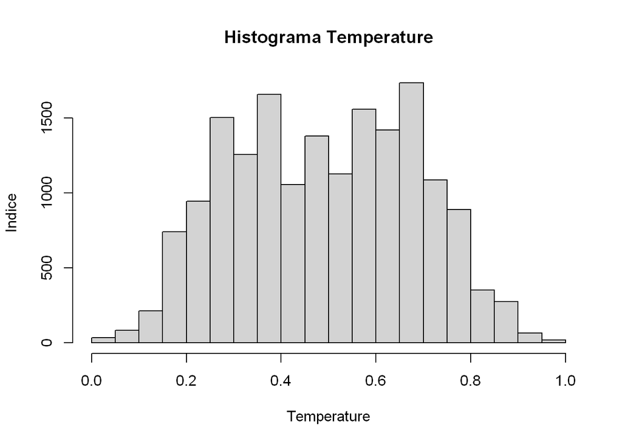

```r
# histograma
hist(hour$temp, main="Histograma Temperature", xlab="Temperature",  ylab="Indice", nclass=hour.temp.sturges.nclass)
```

### Diagrama de Extremos e Quartis

```r
# Outliers
cat("\nOutliers\n")
```

```
##
## Outliers
```

```r
hour.temperatura.outliers <- boxplot.stats(hour$temp)$out
hour.temperatura.outliers
```

```
## numeric(0)
```

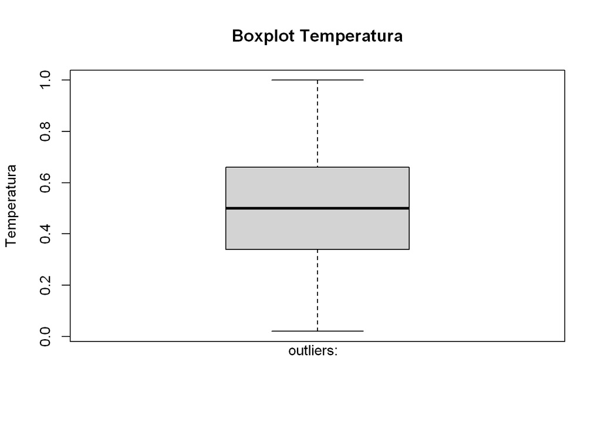

```r
# Diagrama
boxplot(hour$temp, ylab="Temperatura", main="Boxplot Temperatura")

mtext(text = paste("outliers: ", paste(hour.temperatura.outliers, collapse = ", ")), side = 1)
```

Verificou-se que não existem outliers presentes no gráfico porque os resultados da coluna não estão fora do diagrama de extremos e quartis.

## **1.1. temp**

### Medidas de Tendência Central

```r
# Contagem de valores
table(hour.day$temp)
```

```
##
## 0.02 0.04 0.06 0.08  0.1 0.12 0.14 0.16 0.18  0.2 0.22 0.24 0.26 0.28  0.3 0.32
##    5    4    6    8   17   31   52  103   65  169  194  198  221  133  272  295
## 0.34 0.36 0.38  0.4 0.42 0.44 0.46 0.48  0.5 0.52 0.54 0.56 0.58  0.6 0.62 0.64
##  318  333  200  334  289  219  248  152  249  271  265  274  145  315  305  322
## 0.66 0.68  0.7 0.72 0.74 0.76 0.78  0.8 0.82 0.84 0.86 0.88  0.9 0.92 0.94 0.96
##  298  144  343  325  332  285  113  265  171  118  117   47   86   47   17   16
## 0.98    1
##    1    1
```

#### Moda

```r
hour.day.temp.sort <- sort(hour.day$temp)

hour.day.temp.mode <- moda(hour.day.temp.sort)
hour.day.temp.mode
```

```
## [1] 0.7
```

#### Média

```r
hour.day.temperatura.media <- mean(hour.day$temp)
hour.day.temperatura.media
```

```
## [1] 0.5236736
```

#### Mediana

```r
hour.day.temperatura.mediana <- median(hour.day$temp)
hour.day.temperatura.mediana
```

```
## [1] 0.52
```

#### Quartil

```r
hour.day.temperatura.quantile <- quantile(hour.day$temp)
hour.day.temperatura.quantile
```

```
##   0%  25%  50%  75% 100%
## 0.02 0.36 0.52 0.70 1.00
```

### Medidas de Dispersão Central

#### Variância

```r
hour.day.temperatura.variancia <- var(hour.day$temp)
hour.day.temperatura.variancia
```

```
## [1] 0.0401759
```

#### Desvio Padrão

```r
hour.day.temperatura.desvio_padrao <- sd(hour.day$temp)
hour.day.temperatura.desvio_padrao
```

```
## [1] 0.2004393
```

#### Coeficiente de Variação

```r
hour.day.temperatura.coeficiente_variacao <- coeficiente_variacao(hour.day$temp)
hour.day.temperatura.coeficiente_variacao
```

```
## [1] 38.27561
```

### Valores Extremos

#### Máximo

```r
hour.day.temperatura.maxima <- max(hour.day$temp)
hour.day.temperatura.maxima
```

```
## [1] 1
```

#### Mínimo

```r
hour.day.temperatura.minima <- min(hour.day$temp)
hour.day.temperatura.minima
```

```
## [1] 0.02
```

### Medidas de Assimetria

```r
hour.day.temperatura.assimetria <- assimetria(hour.day$temp)
hour.day.temperatura.assimetria
```

```
## [1] -0.03380892
```

De acordo com o resultado, é assimétrica negativa fraca (ou enviesada para a esquerda).

### Medidas de Curtose ou Achatamento

```r
hour.day.temperatura.achatamento <- achatamento(hour.day$temp)
hour.day.temperatura.achatamento
```

```
## [1] -0.998132
```

Curva platicúrtica, achatada, o que significa que os valores estão pouco concentrados em torno da média e, consequentemente, existe uma variação elevada.

### Histograma

```r
# formula de sturges
cat("Número de classes\n")
```

```
## Número de classes
```

```r
hour.day.temp.sturges.nclass <- sturges(hour.day$temp)
hour.day.temp.sturges.nclass
```

```
## [1] 14
```

```r
# amplitude da classe
cat("\nAmplitude da classe\n")
```

```
##
## Amplitude da classe
```

```r
hour.day.temp.sturges.amplitude <- amplitude(hour.day$temp)
hour.day.temp.sturges.amplitude
```

```
## [1] 0.07
```

```r
# tabela de frequencias
cat("\nClasses\n")
```

```
##
## Classes
```

```r
hour.day.temp.sturges.breaks <- seq(hour.day.temperatura.minima, hour.day.temperatura.maxima, hour.day.temp.sturges.amplitude)
hour.day.temp.sturges.breaks
```

```
##  [1] 0.02 0.09 0.16 0.23 0.30 0.37 0.44 0.51 0.58 0.65 0.72 0.79 0.86 0.93 1.00
```

```r
cat("\nTabela de frequências\n")
```

```
##
## Tabela de frequências
```

```r
table(cut(hour.day$temp, breaks=hour.day.temp.sturges.breaks))
```

```
##
## (0.02,0.09] (0.09,0.16] (0.16,0.23]  (0.23,0.3]  (0.3,0.37] (0.37,0.44]
##          18         100         531         824         946         823
## (0.44,0.51] (0.51,0.58] (0.58,0.65] (0.65,0.72] (0.72,0.79] (0.79,0.86]
##         868         955         942        1110         730         554
## (0.86,0.93]    (0.93,1]
##         297          34
```

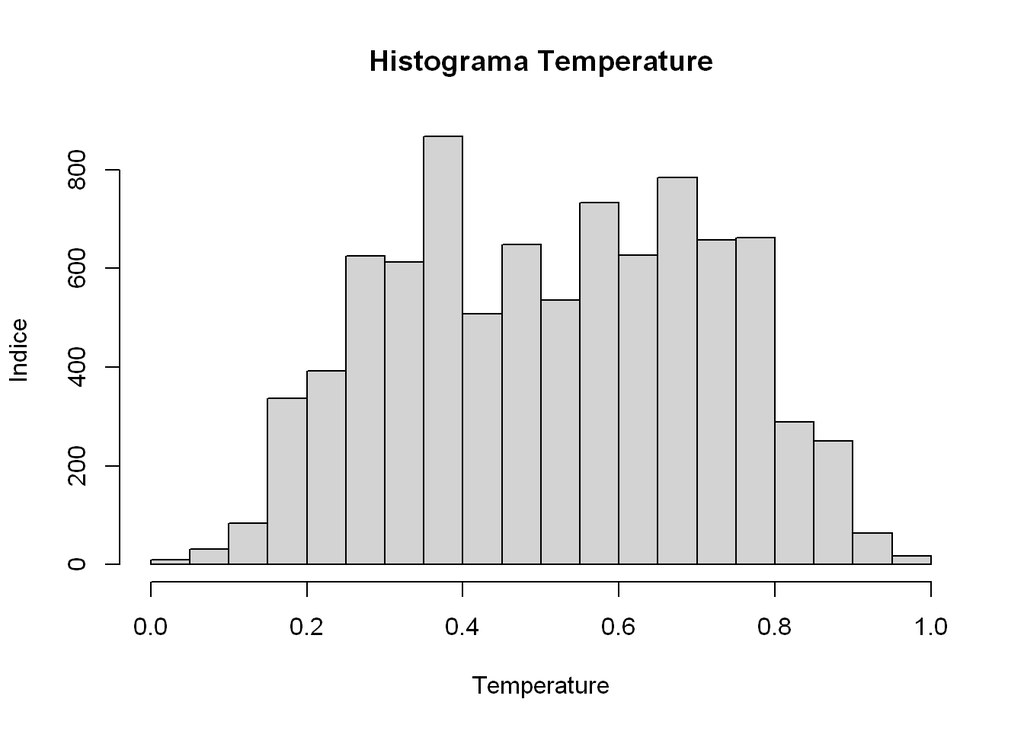

```r
# histograma
hist(hour.day$temp, main="Histograma Temperature", xlab="Temperature",  ylab="Indice", nclass=hour.day.temp.sturges.nclass)
```

A partir do histograma, pode-se observar que o valor do índice aumenta no intervalo 0.02, a 0.72 e começa a diminuir de 0.72 a 1 tendo um comportamento crescente até atingir o maior índice no intervalo de 0.65 a 0.72.

### Diagrama de Extremos e Quartis

```r
# Outliers
cat("\nOutliers\n")
```

```
##
## Outliers
```

```r
hour.day.temperatura.outliers <- boxplot.stats(hour.day$temp)$out
hour.day.temperatura.outliers
```

```
## numeric(0)
```

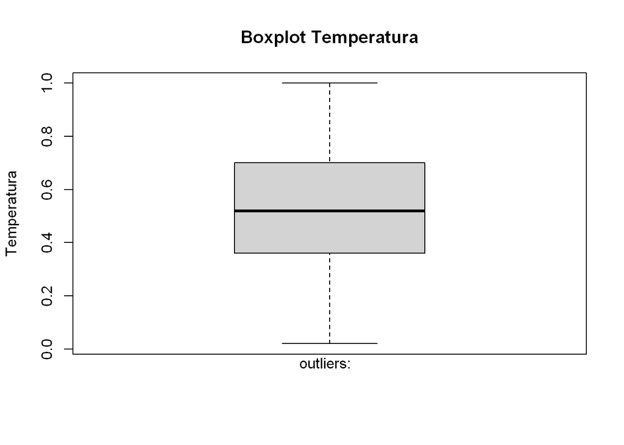

```r
# Diagrama
boxplot(hour.day$temp, ylab="Temperatura", main="Boxplot Temperatura")

mtext(text = paste("outliers: ", paste(hour.day.temperatura.outliers, collapse = ", ")), side = 1)
```

Verificou-se que não existem outliers presentes no gráfico porque os resultados da coluna não estão fora do diagrama de extremos e quartis.

## **1.2. temp**

### Medidas de Tendência Central

```r
# Contagem de valores
table(hour.night$temp)
```

```
##
## 0.02 0.04 0.06 0.08  0.1 0.12 0.14 0.16 0.18  0.2 0.22 0.24 0.26 0.28  0.3 0.32
##   12   12   10    9   34   45   86  127   90  185  227  324  338  168  369  316
## 0.34 0.36 0.38  0.4 0.42 0.44 0.46 0.48  0.5 0.52 0.54 0.56 0.58  0.6 0.62 0.64
##  327  338  172  280  259  288  311  136  282  285  304  305  160  360  421  370
## 0.66 0.68  0.7 0.72 0.74 0.76 0.78  0.8 0.82 0.84 0.86 0.88  0.9 0.92
##  395  205  347  245  184  111   56   60   42   20   14    6    4    2
```

#### Moda

```r
hour.night.temp.sort <- sort(hour.night$temp)

hour.night.temp.mode <- moda(hour.night.temp.sort)
hour.night.temp.mode
```

```
## [1] 0.62
```

#### Média

```r
hour.night.temperatura.media <- mean(hour.night$temp)
hour.night.temperatura.media
```

```
## [1] 0.4700012
```

#### Mediana

```r
hour.night.temperatura.mediana <- median(hour.night$temp)
hour.night.temperatura.mediana
```

```
## [1] 0.46
```

#### Quartil

```r
hour.night.temperatura.quantile <- quantile(hour.night$temp)
hour.night.temperatura.quantile
```

```
##   0%  25%  50%  75% 100%
## 0.02 0.32 0.46 0.62 0.92
```

### Medidas de Dispersão Central

#### Variância

```r
hour.night.temperatura.variancia <- var(hour.night$temp)
hour.night.temperatura.variancia
```

```
## [1] 0.03250075
```

#### Desvio Padrão

```r
hour.night.temperatura.desvio_padrao <- sd(hour.night$temp)
hour.night.temperatura.desvio_padrao
```

```
## [1] 0.1802797
```

#### Coeficiente de Variação

```r
hour.night.temperatura.coeficiente_variacao <- coeficiente_variacao(hour.night$temp)
hour.night.temperatura.coeficiente_variacao
```

```
## [1] 38.35728
```

### Valores Extremos

#### Máximo

```r
hour.night.temperatura.maxima <- max(hour.night$temp)
hour.night.temperatura.maxima
```

```
## [1] 0.92
```

#### Mínimo

```r
hour.night.temperatura.minima <- min(hour.night$temp)
hour.night.temperatura.minima
```

```
## [1] 0.02
```

### Medidas de Assimetria

```r
hour.night.temperatura.assimetria <- assimetria(hour.night$temp)
hour.night.temperatura.assimetria
```

```
## [1] -0.07372828
```

De acordo com o resultado, é assimétrica negativa fraca (ou enviesada para a esquerda).

### Medidas de Curtose ou Achatamento

```r
hour.night.temperatura.achatamento <- achatamento(hour.night$temp)
hour.night.temperatura.achatamento
```

```
## [1] -1.022793
```

Curva platicúrtica, achatada, o que significa que os valores estão pouco concentrados em torno da média e, consequentemente, existe uma variação elevada.

### Histograma

```r
# formula de sturges
cat("Número de classes\n")
```

```
## Número de classes
```

```r
hour.night.temp.sturges.nclass <- sturges(hour.night$temp)
hour.night.temp.sturges.nclass
```

```
## [1] 14
```

```r
# amplitude da classe
cat("\nAmplitude da classe\n")
```

```
##
## Amplitude da classe
```

```r
hour.night.temp.sturges.amplitude <- amplitude(hour.night$temp)
hour.night.temp.sturges.amplitude
```

```
## [1] 0.06428571
```

```r
# tabela de frequencias
cat("\nClasses\n")
```

```
##
## Classes
```

```r
hour.night.temp.sturges.breaks <- seq(hour.night.temperatura.minima, hour.night.temperatura.maxima, hour.night.temp.sturges.amplitude)
hour.night.temp.sturges.breaks
```

```
##  [1] 0.02000000 0.08428571 0.14857143 0.21285714 0.27714286 0.34142857
##  [7] 0.40571429 0.47000000 0.53428571 0.59857143 0.66285714 0.72714286
## [13] 0.79142857 0.85571429 0.92000000
```

```r
cat("\nTabela de frequências\n")
```

```
##
## Tabela de frequências
```

```r
table(cut(hour.night$temp, breaks=hour.night.temp.sturges.breaks))
```

```
##
##  (0.02,0.0843] (0.0843,0.149]  (0.149,0.213]  (0.213,0.277]  (0.277,0.341]
##             31            165            402            889           1180
##  (0.341,0.406]   (0.406,0.47]   (0.47,0.534]  (0.534,0.599]  (0.599,0.663]
##            790            858            703            769           1546
##  (0.663,0.727]  (0.727,0.791]  (0.791,0.856]   (0.856,0.92]
##            797            351            122             26
```

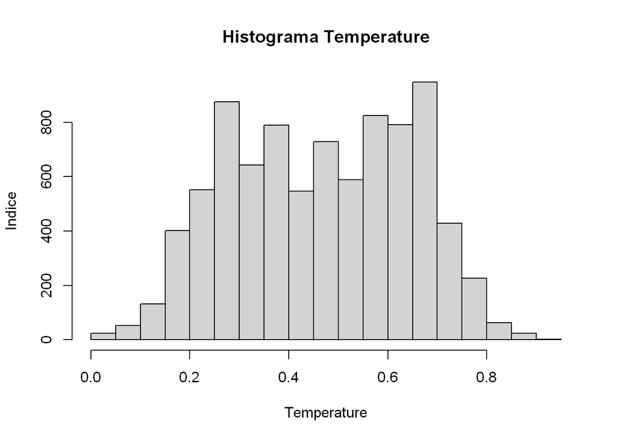

```r
# histograma
hist(hour.night$temp, main="Histograma Temperature", xlab="Temperature",  ylab="Indice", nclass=hour.night.temp.sturges.nclass)
```

A partir do histograma, pode-se observar que o valor do índice aumenta no intervalo 0.02 a 0.663 e começa a diminuir de 0.663 at´r 0.92 tendo um comportamento crescente até atingir o maior índice no intervalo de 0.599 a 0.663.

### Diagrama de Extremos e Quartis

```r
# Outliers
cat("\nOutliers\n")
```

```
##
## Outliers
```

```r
hour.night.temperatura.outliers <- boxplot.stats(hour.night$temp)$out
hour.night.temperatura.outliers
```

```
## numeric(0)
```

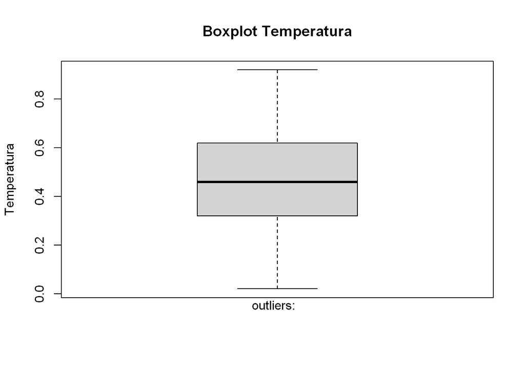

```r
# Diagrama
boxplot(hour.night$temp, ylab="Temperatura", main="Boxplot Temperatura")

mtext(text = paste("outliers: ", paste(hour.night.temperatura.outliers, collapse = ", ")), side = 1)
```

Verificou-se que não existem outliers presentes no gráfico porque os resultados da coluna não estão fora do diagrama de extremos e quartis.

## **2.. weekday**

### Classificação da variável

Variável qualitativa ordinal, e é tratada como quantitativa discreta normal, visto que, não tem grande variedade de variaveis distintas.

### Medidas de Tendência Central

#### Moda

```r
hour.weekday.moda <- moda(hour$weekday)
hour.weekday.moda
```

```
## [1] 6
```

#### Média

```r
hour.weekday.media <- mean(hour$weekday)
hour.weekday.media
```

```
## [1] 3.003683
```

#### Mediana

```r
hour.weekday.mediana <- median(hour$weekday)
hour.weekday.mediana
```

```
## [1] 3
```

#### Quartil

```r
hour.weekday.quantile <- quantile(hour$weekday)
hour.weekday.quantile
```

```
##   0%  25%  50%  75% 100%
##    0    1    3    5    6
```

### Medidas de Dispersão Central

#### Variância

```r
hour.weekday.variancia <- var(hour$weekday)
hour.weekday.variancia
```

```
## [1] 4.023119
```

#### Desvio Padrão

```r
hour.weekday.desvio_padrao <- sd(hour$weekday)
hour.weekday.desvio_padrao
```

```
## [1] 2.005771
```

#### Coeficiente de Variação

```r
hour.weekday.coeficiente_variacao <- coeficiente_variacao(hour$weekday)
hour.weekday.coeficiente_variacao
```

```
## [1] 66.77708
```

### Valores Extremos

#### Máximo

```r
hour.weekday.maxima <- max(hour$weekday)
hour.weekday.maxima
```

```
## [1] 6
```

#### Mínimo

```r
hour.weekday.minima <- min(hour$weekday)
hour.weekday.minima
```

```
## [1] 0
```

### Medidas de Assimetria

```r
hour.weekday.assimetria <- assimetria(hour$weekday)
hour.weekday.assimetria
```

```
## [1] -0.002997704
```

De acordo com o resultado, é assimétrica negativa (ou enviesada para a esquerda).

### Medidas de Curtose ou Achatamento

```r
hour.weekday.achatamento <- achatamento(hour$weekday)
hour.weekday.achatamento
```

```
## [1] -1.256181
```

Curva platicúrtica, achatada, o que significa que os valores estão pouco concentrados em torno da média e, consequentemente, existe uma variação elevada.

### Grafico de barras

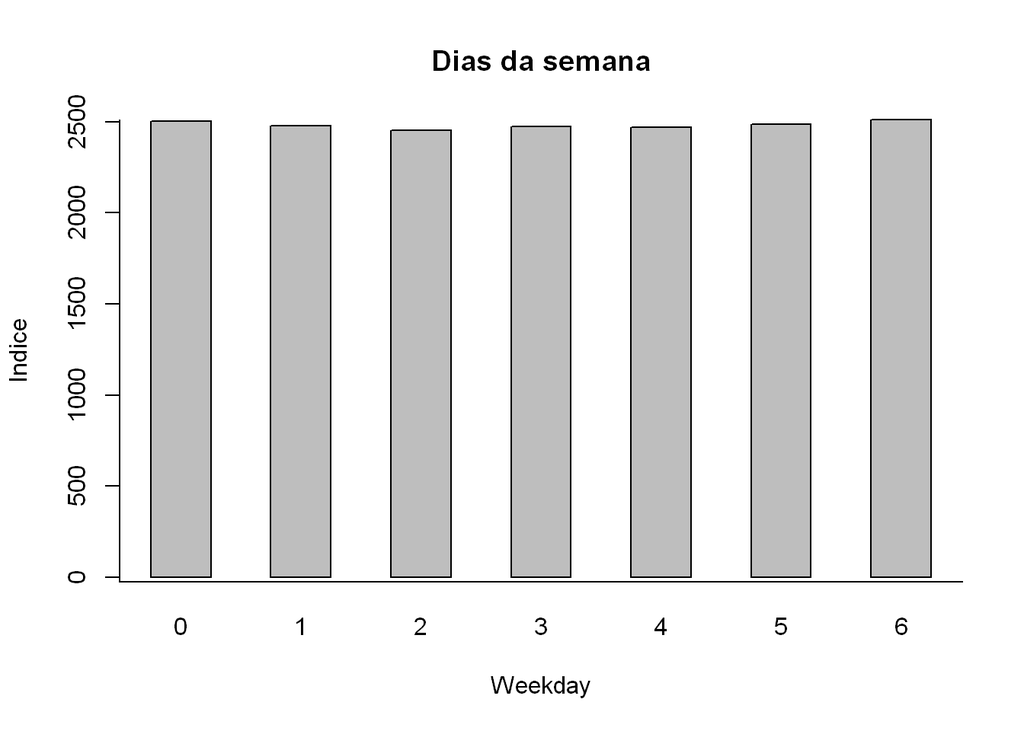

```r
count <- table(hour$weekday)

barplot(count, main="Dias da semana", xlab="Weekday",  ylab="Indice", space =1.0)
box(bty="L")
```

### Diagrama de Extremos e Quartis

```r
# Outliers
cat("\nOutliers\n")
```

```
##
## Outliers
```

```r
hour.weekday.outliers <- boxplot.stats(hour$weekday)$out
hour.weekday.outliers
```

```
## integer(0)
```

```r
# Diagrama
boxplot(hour$weekday, ylab="Dia da Semana", main="Boxplot Dia da Semana")

mtext(text = paste("outliers: ", paste(hour.weekday.outliers, collapse = ", ")), side = 1)
```

[output not shown]

Verificou-se que não existem outliers presentes no gráfico porque os resultados da coluna não estão fora do diagrama de extremos e quartis.

## **2.1. weekday**

### Classificação da variável

Variável qualitativa ordinal, e é tratada como quantitativa discreta normal, visto que, não tem grande variedade de variaveis distintas.

### Medidas de Tendência Central

#### Moda

```r
hour.day.weekday.moda <- moda(hour.day$weekday)
hour.day.weekday.moda
```

```
## [1] 0
```

#### Média

```r
hour.day.weekday.media <- mean(hour.day$weekday)
hour.day.weekday.media
```

```
## [1] 2.999886
```

#### Mediana

```r
hour.day.weekday.mediana <- median(hour.day$weekday)
hour.day.weekday.mediana
```

```
## [1] 3
```

#### Quartil

```r
hour.day.weekday.quantile <- quantile(hour.day$weekday)
hour.day.weekday.quantile
```

```
##   0%  25%  50%  75% 100%
##    0    1    3    5    6
```

### Medidas de Dispersão Central

#### Variância

```r
hour.day.weekday.variancia <- var(hour.day$weekday)
hour.day.weekday.variancia
```

```
## [1] 4.020945
```

#### Desvio Padrão

```r
hour.day.weekday.desvio_padrao <- sd(hour.day$weekday)
hour.day.weekday.desvio_padrao
```

```
## [1] 2.00523
```

#### Coeficiente de Variação

```r
hour.day.weekday.coeficiente_variacao <- coeficiente_variacao(hour.day$weekday)
hour.day.weekday.coeficiente_variacao
```

```
## [1] 66.84353
```

### Valores Extremos

#### Máximo

```r
hour.day.weekday.maxima <- max(hour.day$weekday)
hour.day.weekday.maxima
```

```
## [1] 6
```

#### Mínimo

```r
hour.day.weekday.minima <- min(hour.day$weekday)
hour.day.weekday.minima
```

```
## [1] 0
```

### Medidas de Assimetria

```r
hour.day.weekday.assimetria <- assimetria(hour.day$weekday)
hour.day.weekday.assimetria
```

```
## [1] -0.0001836458
```

De acordo com o resultado, é assimétrica negativa (ou enviesada para a esquerda).

### Medidas de Curtose ou Achatamento

```r
hour.day.weekday.achatamento <- achatamento(hour.day$weekday)
hour.day.weekday.achatamento
```

```
## [1] -1.255535
```

Curva platicúrtica, achatada, o que significa que os valores estão pouco concentrados em torno da média e, consequentemente, existe uma variação elevada.

### Grafico de barras

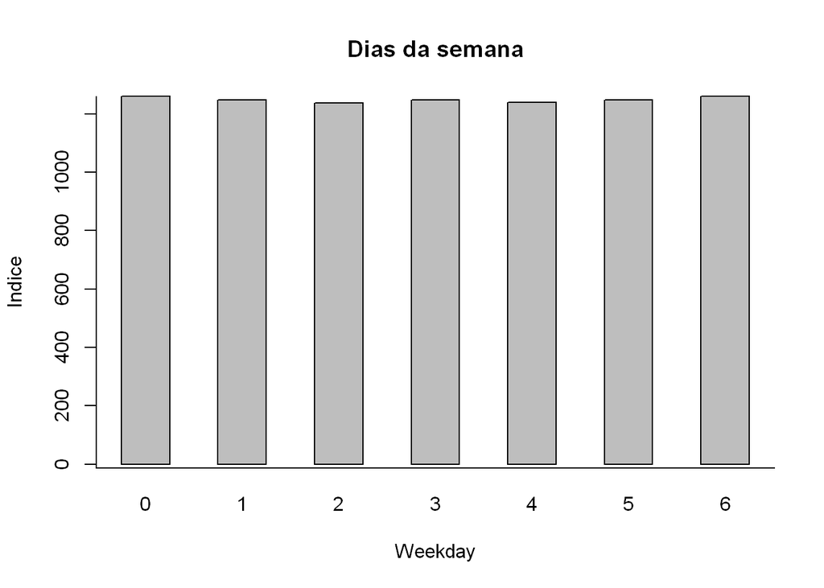

```r
count <- table(hour.day$weekday)

barplot(count, main="Dias da semana", xlab="Weekday",  ylab="Indice", space =1.0)
box(bty="L")
```

### Diagrama de Extremos e Quartis

```r
# Outliers
cat("\nOutliers\n")
```

```
##
## Outliers
```

```r
hour.day.weekday.outliers <- boxplot.stats(hour.day$weekday)$out
hour.day.weekday.outliers
```

```
## integer(0)
```

```r
# Diagrama
boxplot(hour.day$weekday, ylab="Dia da Semana", main="Boxplot Dia da Semana")

mtext(text = paste("outliers: ", paste(hour.day.weekday.outliers, collapse = ", ")), side = 1)
```

[output not shown]

Verificou-se que não existem outliers presentes no gráfico porque os resultados da coluna não estão fora do diagrama de extremos e quartis.

## **2.2. weekday**

### Classificação da variável

Variável qualitativa ordinal, e é tratada como quantitativa discreta normal, visto que, não tem grande variedade de variaveis distintas.

### Medidas de Tendência Central

#### Moda

```r
hour.night.weekday.moda <- moda(hour.night$weekday)
hour.night.weekday.moda
```

```
## [1] 6
```

#### Média

```r
hour.night.weekday.media <- mean(hour.night$weekday)
hour.night.weekday.media
```

```
## [1] 3.007522
```

#### Mediana

```r
hour.night.weekday.mediana <- median(hour.night$weekday)
hour.night.weekday.mediana
```

```
## [1] 3
```

#### Quartil

```r
hour.night.weekday.quantile <- quantile(hour.night$weekday)
hour.night.weekday.quantile
```

```
##   0%  25%  50%  75% 100%
##    0    1    3    5    6
```

### Medidas de Dispersão Central

#### Variância

```r
hour.night.weekday.variancia <- var(hour.night$weekday)
hour.night.weekday.variancia
```

```
## [1] 4.025754
```

#### Desvio Padrão

```r
hour.night.weekday.desvio_padrao <- sd(hour.night$weekday)
hour.night.weekday.desvio_padrao
```

```
## [1] 2.006428
```

#### Coeficiente de Variação

```r
hour.night.weekday.coeficiente_variacao <- coeficiente_variacao(hour.night$weekday)
hour.night.weekday.coeficiente_variacao
```

```
## [1] 66.71366
```

### Valores Extremos

#### Máximo

```r
hour.night.weekday.maxima <- max(hour.night$weekday)
hour.night.weekday.maxima
```

```
## [1] 6
```

#### Mínimo

```r
hour.night.weekday.minima <- min(hour.night$weekday)
hour.night.weekday.minima
```

```
## [1] 0
```

### Medidas de Assimetria

```r
hour.night.weekday.assimetria <- assimetria(hour.night$weekday)
hour.night.weekday.assimetria
```

```
## [1] -0.005844616
```

De acordo com o resultado, é assimétrica negativa (ou enviesada para a esquerda).

### Medidas de Curtose ou Achatamento

```r
hour.night.weekday.achatamento <- achatamento(hour.night$weekday)
hour.night.weekday.achatamento
```

```
## [1] -1.257213
```

Curva platicúrtica, achatada, o que significa que os valores estão pouco concentrados em torno da média e, consequentemente, existe uma variação elevada.

### Grafico de barras

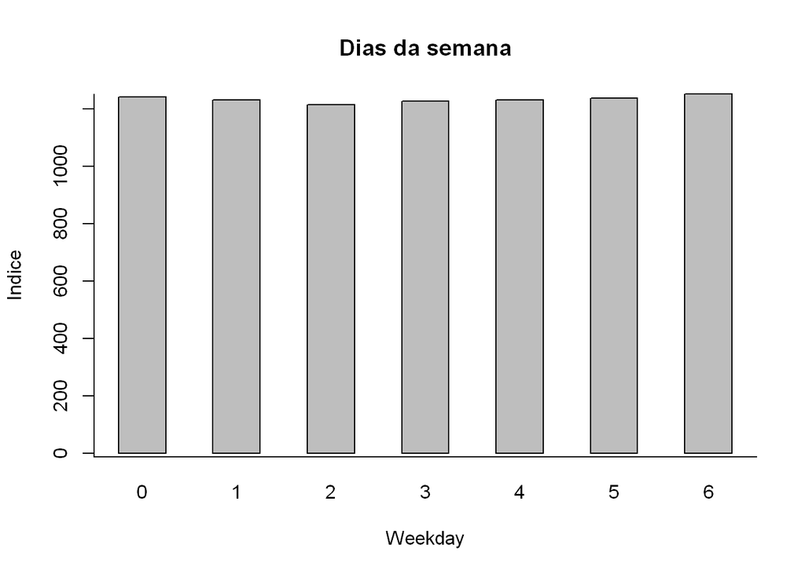

```r
count <- table(hour.night$weekday)

barplot(count, main="Dias da semana", xlab="Weekday",  ylab="Indice", space =1.0)
box(bty="L")
```

### Diagrama de Extremos e Quartis

```r
# Outliers
cat("\nOutliers\n")
```

```
##
## Outliers
```

```r
hour.night.weekday.outliers <- boxplot.stats(hour.night$weekday)$out
hour.night.weekday.outliers
```

```
## integer(0)
```

```r
# Diagrama
boxplot(hour.night$weekday, ylab="Dia da Semana", main="Boxplot Dia da Semana")

mtext(text = paste("outliers: ", paste(hour.night.weekday.outliers, collapse = ", ")), side = 1)
```

[output not shown]

Verificou-se que não existem outliers presentes no gráfico porque os resultados da coluna não estão fora do diagrama de extremos e quartis.

## **3.. casual**

### Classificação da variável

Variável quantitativa discreta, e é tratada como quantitativa discreta normal, visto que, não tem grande variedade de variaveis distintas.

### Medidas de Tendência Central

#### Moda

```r
hour.casual.moda <- moda(hour$casual)
hour.casual.moda
```

```
## [1] 0
```

#### Média

```r
hour.casual.media <- mean(hour$casual)
hour.casual.media
```

```
## [1] 35.67622
```

#### Mediana

```r
hour.casual.mediana <- median(hour$casual)
hour.casual.mediana
```

```
## [1] 17
```

#### Quartil

```r
hour.casual.quantile <- quantile(hour$casual)
hour.casual.quantile
```

```
##   0%  25%  50%  75% 100%
##    0    4   17   48  367
```

### Medidas de Dispersão Central

#### Variância

```r
hour.casual.variancia <- var(hour$casual)
hour.casual.variancia
```

```
## [1] 2430.986
```

#### Desvio Padrão

```r
hour.casual.desvio_padrao <- sd(hour$casual)
hour.casual.desvio_padrao
```

```
## [1] 49.30503
```

#### Coeficiente de Variação

```r
hour.casual.coeficiente_variacao <- coeficiente_variacao(hour$casual)
hour.casual.coeficiente_variacao
```

```
## [1] 138.2014
```

### Valores Extremos

#### Máximo

```r
hour.casual.maxima <- max(hour$casual)
hour.casual.maxima
```

```
## [1] 367
```

#### Mínimo

```r
hour.casual.minima <- min(hour$casual)
hour.casual.minima
```

```
## [1] 0
```

### Medidas de Assimetria

```r
hour.casual.assimetria <- assimetria(hour$casual)
hour.casual.assimetria
```

```
## [1] 2.498805
```

De acordo com o resultado, é assimétrica positiva (ou enviesada para a direita).

### Medidas de Curtose ou Achatamento

```r
hour.casual.achatamento <- achatamento(hour$casual)
hour.casual.achatamento
```

```
## [1] 7.567262
```

Curva leptocúrtica, alongada, o que significa que os valores estão muito concentrados em torno da média e, consequentemente, existe uma variação é pouco elevada.

### Histograma

```r
# formula de sturges
cat("Número de classes\n")
```

```
## Número de classes
```

```r
hour.casual.sturges.nclass <- sturges(hour$casual)
hour.casual.sturges.nclass
```

```
## [1] 15
```

```r
# amplitude da classe
cat("\nAmplitude da classe\n")
```

```
##
## Amplitude da classe
```

```r
hour.casual.sturges.amplitude <- amplitude(hour$casual)
hour.casual.sturges.amplitude
```

```
## [1] 24.46667
```

```r
# tabela de frequencias
cat("\nClasses\n")
```

```
##
## Classes
```

```r
hour.casual.sturges.breaks <- seq(hour.casual.minima, hour.casual.maxima, hour.casual.sturges.amplitude)
hour.casual.sturges.breaks
```

```
##  [1]   0.00000  24.46667  48.93333  73.40000  97.86667 122.33333 146.80000
##  [8] 171.26667 195.73333 220.20000 244.66667 269.13333 293.60000 318.06667
## [15] 342.53333 367.00000
```

```r
cat("\nTabela de frequências\n")
```

```
##
## Tabela de frequências
```

```r
table(cut(hour$casual, breaks=hour.casual.sturges.breaks))
```

```
##
##    (0,24.5] (24.5,48.9] (48.9,73.4] (73.4,97.9]  (97.9,122]   (122,147]
##        8547        2918        1795         947         533         278
##   (147,171]   (171,196]   (196,220]   (220,245]   (245,269]   (269,294]
##         212         186         109         112          82          38
##   (294,318]   (318,343]   (343,367]
##          21          10          10
```

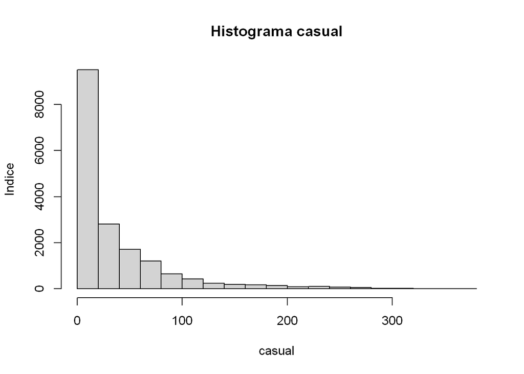

```r
# histograma
hist(hour$casual, main="Histograma casual", xlab="casual",  ylab="Indice", nclass=hour.casual.sturges.nclass)
```

A partir do histograma, pode-se observar que o valor do índice diminui no intervalo 0, a 367, tendo um comportamento decrescente até atingir o maior índice no intervalo de 0 a 24.5.

### Diagrama de Extremos e Quartis

```r
# Outliers
cat("\nOutliers\n")
```

```
##
## Outliers
```

```r
hour.casual.outliers <- boxplot.stats(hour$casual)$out
hour.casual.outliers
```

[output not shown]

[output cut: 52 more lines]

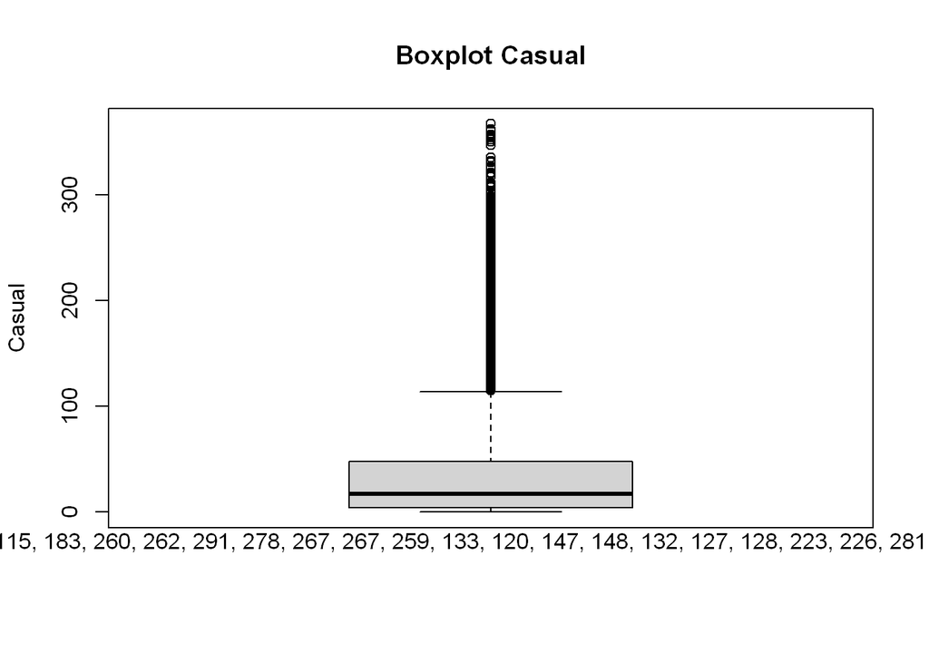

```r
# Diagrama
boxplot(hour$casual, ylab="Casual", main="Boxplot Casual")

mtext(text = paste("outliers: ", paste(hour.casual.outliers, collapse = ", ")), side = 1)
```

Verificou-se que existem outliers presentes no gráfico.

## **3.1. casual**

### Classificação da variável

Variável quantitativa discreta, e é tratada como quantitativa discreta normal, visto que, não tem grande variedade de variaveis distintas.

### Medidas de Tendência Central

#### Moda

```r
hour.day.casual.moda <- moda(hour.day$casual)
hour.day.casual.moda
```

```
## [1] 6
```

#### Média

```r
hour.day.casual.media <- mean(hour.day$casual)
hour.day.casual.media
```

```
## [1] 55.84882
```

#### Mediana

```r
hour.day.casual.mediana <- median(hour.day$casual)
hour.day.casual.mediana
```

```
## [1] 36
```

#### Quartil

```r
hour.day.casual.quantile <- quantile(hour.day$casual)
hour.day.casual.quantile
```

```
##   0%  25%  50%  75% 100%
##    0   15   36   74  367
```

### Medidas de Dispersão Central

#### Variância

```r
hour.day.casual.variancia <- var(hour.day$casual)
hour.day.casual.variancia
```

```
## [1] 3436.565
```

#### Desvio Padrão

```r
hour.day.casual.desvio_padrao <- sd(hour.day$casual)
hour.day.casual.desvio_padrao
```

```
## [1] 58.62222
```

#### Coeficiente de Variação

```r
hour.day.casual.coeficiente_variacao <- coeficiente_variacao(hour.day$casual)
hour.day.casual.coeficiente_variacao
```

```
## [1] 104.9659
```

### Valores Extremos

#### Máximo

```r
hour.day.casual.maxima <- max(hour.day$casual)
hour.day.casual.maxima
```

```
## [1] 367
```

#### Mínimo

```r
hour.day.casual.minima <- min(hour.day$casual)
hour.day.casual.minima
```

```
## [1] 0
```

### Medidas de Assimetria

```r
hour.day.casual.assimetria <- assimetria(hour.day$casual)
hour.day.casual.assimetria
```

```
## [1] 1.899737
```

De acordo com o resultado, é assimétrica positiva (ou enviesada para a direita).

### Medidas de Curtose ou Achatamento

```r
hour.day.casual.achatamento <- achatamento(hour.day$casual)
hour.day.casual.achatamento
```

```
## [1] 3.905951
```

Curva leptocúrtica, alongada, o que significa que os valores estão muito concentrados em torno da média e, consequentemente, existe uma variação é pouco elevada.

### Histograma

```r
# formula de sturges
cat("Número de classes\n")
```

```
## Número de classes
```

```r
hour.day.casual.sturges.nclass <- sturges(hour.day$casual)
hour.day.casual.sturges.nclass
```

```
## [1] 14
```

```r
# amplitude da classe
cat("\nAmplitude da classe\n")
```

```
##
## Amplitude da classe
```

```r
hour.day.casual.sturges.amplitude <- amplitude(hour.day$casual)
hour.day.casual.sturges.amplitude
```

```
## [1] 26.21429
```

```r
# tabela de frequencias
cat("\nClasses\n")
```

```
##
## Classes
```

```r
hour.day.casual.sturges.breaks <- seq(hour.day.casual.minima, hour.day.casual.maxima, hour.day.casual.sturges.amplitude)
hour.day.casual.sturges.breaks
```

```
##  [1]   0.00000  26.21429  52.42857  78.64286 104.85714 131.07143 157.28571
##  [8] 183.50000 209.71429 235.92857 262.14286 288.35714 314.57143 340.78571
## [15] 367.00000
```

```r
cat("\nTabela de frequências\n")
```

```
##
## Tabela de frequências
```

```r
table(cut(hour.day$casual, breaks=hour.day.casual.sturges.breaks))
```

```
##
##    (0,26.2] (26.2,52.4] (52.4,78.6]  (78.6,105]   (105,131]   (131,157]
##        3312        2043        1303         672         417         239
##   (157,184]   (184,210]   (210,236]   (236,262]   (262,288]   (288,315]
##         199         149         105         100          55          26
##   (315,341]   (341,367]
##          12          10
```

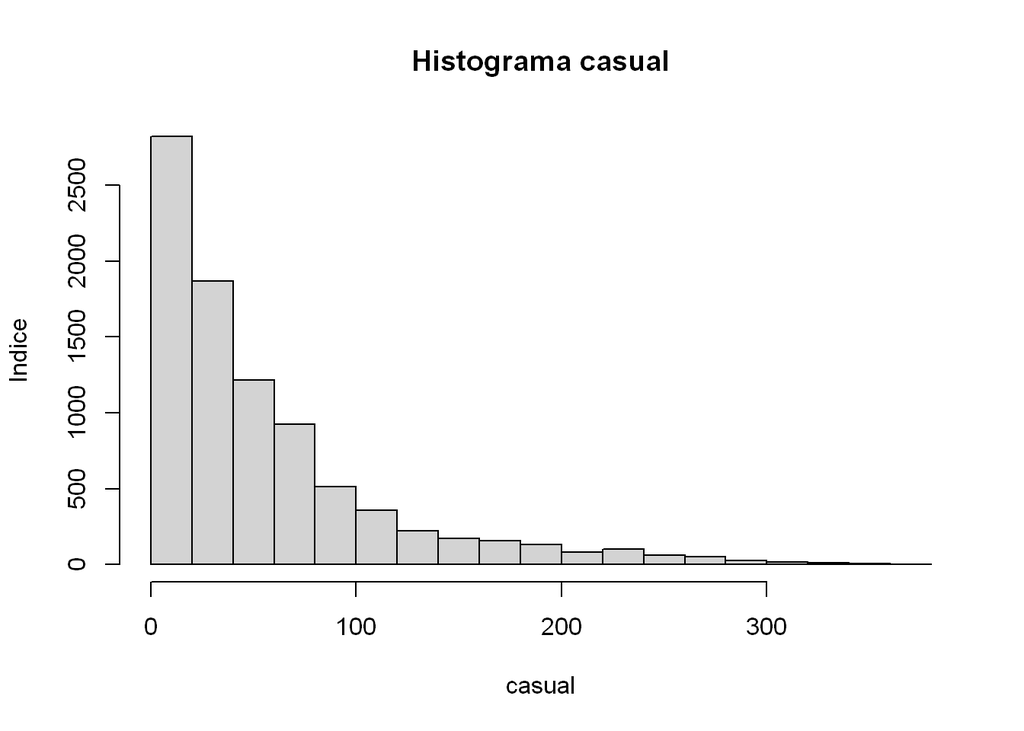

```r
# histograma
hist(hour.day$casual, main="Histograma casual", xlab="casual",  ylab="Indice", nclass=hour.day.casual.sturges.nclass)
```

### Diagrama de Extremos e Quartis

```r
# Outliers
cat("\nOutliers\n")
```

```
##
## Outliers
```

```r
hour.day.casual.outliers <- boxplot.stats(hour.day$casual)$out
hour.day.casual.outliers
```

[output not shown]

[output cut: 20 more lines]

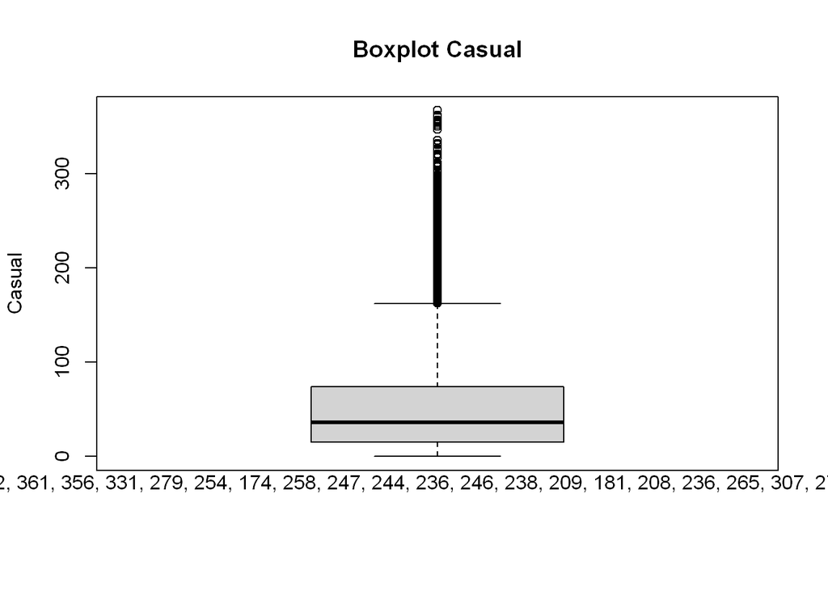

```r
# Diagrama
boxplot(hour.day$casual, ylab="Casual", main="Boxplot Casual")
mtext(text = paste("outliers: ", paste(hour.day.casual.outliers, collapse = ", ")), side = 1)
```

Verificou-se que existem outliers presentes no gráfico.

## **3.2. casual**

### Classificação da variável

Variável quantitativa discreta, e é tratada como quantitativa discreta normal, visto que, não tem grande variedade de variaveis distintas.

### Medidas de Tendência Central

#### Moda

```r
hour.night.casual.moda <- moda(hour.night$casual)
hour.night.casual.moda
```

```
## [1] 0
```

#### Média

```r
hour.night.casual.media <- mean(hour.night$casual)
hour.night.casual.media
```

```
## [1] 15.27717
```

#### Mediana

```r
hour.night.casual.mediana <- median(hour.night$casual)
hour.night.casual.mediana
```

```
## [1] 5
```

#### Quartil

```r
hour.night.casual.quantile <- quantile(hour.night$casual)
hour.night.casual.quantile
```

```
##   0%  25%  50%  75% 100%
##    0    1    5   18  237
```

### Medidas de Dispersão Central

#### Variância

```r
hour.night.casual.variancia <- var(hour.night$casual)
hour.night.casual.variancia
```

```
## [1] 586.6798
```

#### Desvio Padrão

```r
hour.night.casual.desvio_padrao <- sd(hour.night$casual)
hour.night.casual.desvio_padrao
```

```
## [1] 24.22147
```

#### Coeficiente de Variação

```r
hour.night.casual.coeficiente_variacao <- coeficiente_variacao(hour.night$casual)
hour.night.casual.coeficiente_variacao
```

```
## [1] 158.5469
```

### Valores Extremos

#### Máximo

```r
hour.night.casual.maxima <- max(hour.night$casual)
hour.night.casual.maxima
```

```
## [1] 237
```

#### Mínimo

```r
hour.night.casual.minima <- min(hour.night$casual)
hour.night.casual.minima
```

```
## [1] 0
```

### Medidas de Assimetria

```r
hour.night.casual.assimetria <- assimetria(hour.night$casual)
hour.night.casual.assimetria
```

```
## [1] 2.896634
```

De acordo com o resultado, é assimétrica positiva (ou enviesada para a direita).

### Medidas de Curtose ou Achatamento

```r
hour.night.casual.achatamento <- achatamento(hour.night$casual)
hour.night.casual.achatamento
```

```
## [1] 11.42775
```

Curva leptocúrtica, alongada, o que significa que os valores estão muito concentrados em torno da média e, consequentemente, existe uma variação é pouco elevada.

### Histograma

```r
# formula de sturges
cat("Número de classes\n")
```

```
## Número de classes
```

```r
hour.night.casual.sturges.nclass <- sturges(hour.night$casual)
hour.night.casual.sturges.nclass
```

```
## [1] 14
```

```r
# amplitude da classe
cat("\nAmplitude da classe\n")
```

```
##
## Amplitude da classe
```

```r
hour.night.casual.sturges.amplitude <- amplitude(hour.night$casual)
hour.night.casual.sturges.amplitude
```

```
## [1] 16.92857
```

```r
# tabela de frequencias
cat("\nClasses\n")
```

```
##
## Classes
```

```r
hour.night.casual.sturges.breaks <- seq(hour.night.casual.minima, hour.night.casual.maxima, hour.night.casual.sturges.amplitude)
hour.night.casual.sturges.breaks
```

```
##  [1]   0.00000  16.92857  33.85714  50.78571  67.71429  84.64286 101.57143
##  [8] 118.50000 135.42857 152.35714 169.28571 186.21429 203.14286 220.07143
## [15] 237.00000
```

```r
cat("\nTabela de frequências\n")
```

```
##
## Tabela de frequências
```

```r
table(cut(hour.night$casual, breaks=hour.night.casual.sturges.breaks))
```

```
##
##    (0,16.9] (16.9,33.9] (33.9,50.8] (50.8,67.7] (67.7,84.6]  (84.6,102]
##        4826        1063         522         323         200         111
##   (102,118]   (118,135]   (135,152]   (152,169]   (169,186]   (186,203]
##          49          19          14          12          10           3
##   (203,220]   (220,237]
##           1           2
```

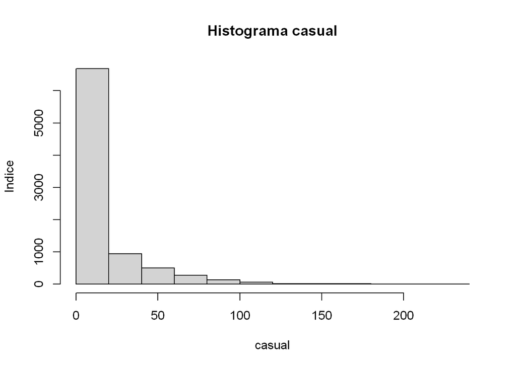

```r
# histograma
hist(hour.night$casual, main="Histograma casual", xlab="casual",  ylab="Indice", nclass=hour.night.casual.sturges.nclass)
```

### Diagrama de Extremos e Quartis

```r
# Outliers
cat("\nOutliers\n")
```

```
##
## Outliers
```

```r
hour.night.casual.outliers <- boxplot.stats(hour.night$casual)$out
hour.night.casual.outliers
```

[output not shown]

[output cut: 38 more lines]

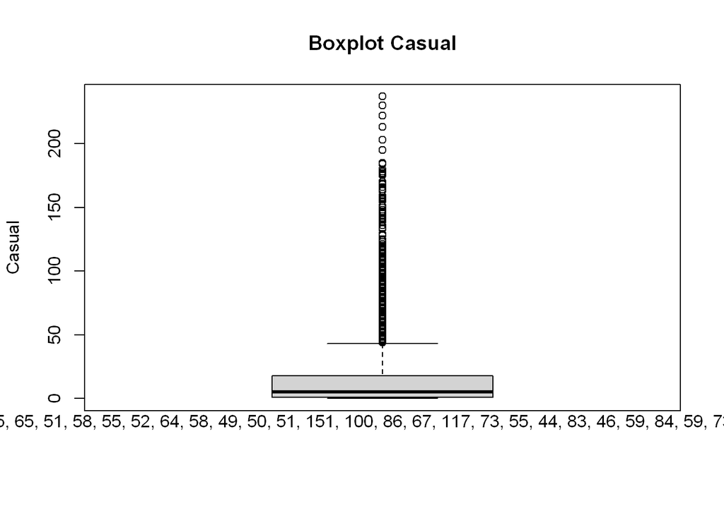

```r
# Diagrama
boxplot(hour.night$casual, ylab="Casual", main="Boxplot Casual")
mtext(text = paste("outliers: ", paste(hour.night.casual.outliers, collapse = ", ")), side = 1)
```

Verificou-se que existem outliers presentes no gráfico.

## **4.. atemp**

### Classificação da variável

Variável quantitativa contínua, e é tratada como quantitativa contínua normal, visto que, tem grande variedade de variaveis distintas.

### Medidas de Tendência Central

#### Moda

```r
hour.atemp.moda <- moda(hour$atemp)
hour.atemp.moda
```

```
## [1] 0.6212
```

#### Média

```r
hour.atemp.media <- mean(hour$atemp)
hour.atemp.media
```

```
## [1] 0.4757751
```

#### Mediana

```r
hour.atemp.mediana <- median(hour$atemp)
hour.atemp.mediana
```

```
## [1] 0.4848
```

#### Quartil

```r
hour.atemp.quantile <- quantile(hour$atemp)
hour.atemp.quantile
```

```
##     0%    25%    50%    75%   100%
## 0.0000 0.3333 0.4848 0.6212 1.0000
```

### Medidas de Dispersão Central

#### Variância

```r
hour.atemp.variancia <- var(hour$atemp)
hour.atemp.variancia
```

```
## [1] 0.0295325
```

#### Desvio Padrão

```r
hour.atemp.desvio_padrao <- sd(hour$atemp)
hour.atemp.desvio_padrao
```

```
## [1] 0.1718502
```

#### Coeficiente de Variação

```r
hour.atemp.coeficiente_variacao <- coeficiente_variacao(hour$atemp)
hour.atemp.coeficiente_variacao
```

```
## [1] 36.12005
```

### Valores Extremos

#### Máximo

```r
hour.atemp.maxima <- max(hour$atemp)
hour.atemp.maxima
```

```
## [1] 1
```

#### Mínimo

```r
hour.atemp.minima <- min(hour$atemp)
hour.atemp.minima
```

```
## [1] 0
```

### Medidas de Assimetria

```r
hour.atemp.assimetria <- assimetria(hour$atemp)
hour.atemp.assimetria
```

```
## [1] -0.09041325
```

De acordo com o resultado, é assimétrica negativa (ou enviesada para a esquerda).

### Medidas de Curtose ou Achatamento

```r
hour.atemp.achatamento <- achatamento(hour$atemp)
hour.atemp.achatamento
```

```
## [1] -0.8457618
```

Curva platicúrtica, achatada, o que significa que os valores estão pouco concentrados em torno da média e, consequentemente, existe uma variação elevada.

### Histograma

```r
# formula de sturges
cat("Número de classes\n")
```

```
## Número de classes
```

```r
hour.atemp.sturges.nclass <- sturges(hour$atemp)
hour.atemp.sturges.nclass
```

```
## [1] 15
```

```r
# amplitude da classe
cat("\nAmplitude da classe\n")
```

```
##
## Amplitude da classe
```

```r
hour.atemp.sturges.amplitude <- amplitude(hour$atemp)
hour.atemp.sturges.amplitude
```

```
## [1] 0.06666667
```

```r
# tabela de frequencias
cat("\nClasses\n")
```

```
##
## Classes
```

```r
hour.atemp.sturges.breaks <- seq(hour.atemp.minima, hour.atemp.maxima, hour.atemp.sturges.amplitude)
hour.atemp.sturges.breaks
```

```
##  [1] 0.00000000 0.06666667 0.13333333 0.20000000 0.26666667 0.33333333
##  [7] 0.40000000 0.46666667 0.53333333 0.60000000 0.66666667 0.73333333
## [13] 0.80000000 0.86666667 0.93333333 1.00000000
```

```r
cat("\nTabela de frequências\n")
```

```
##
## Tabela de frequências
```

```r
table(cut(hour$atemp, breaks=hour.atemp.sturges.breaks))
```

```
##
##     (0,0.0667] (0.0667,0.133]    (0.133,0.2]    (0.2,0.267]  (0.267,0.333]
##             35            162            665           1510           2388
##    (0.333,0.4]    (0.4,0.467]  (0.467,0.533]    (0.533,0.6]    (0.6,0.667]
##           1075           2228           2591           1444           2525
##  (0.667,0.733]    (0.733,0.8]    (0.8,0.867]  (0.867,0.933]      (0.933,1]
##           1862            599            245             44              4
```

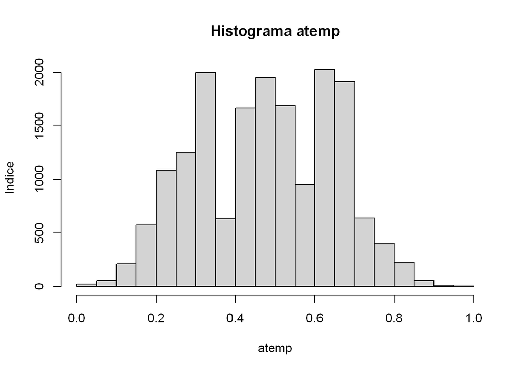

```r
# histograma
hist(hour$atemp, main="Histograma atemp", xlab="atemp",  ylab="Indice", nclass=hour.atemp.sturges.nclass)
```

A partir do histograma, pode-se observar que o valor do índice aumenta no intervalo 0 a 0.5337 e diminui no intervalo 0.5337 a 1, tendo um comportamento crescente e decrescente até atingir o maior índice no intervalo de 0.467 a 0.533.

### Diagrama de Extremos e Quartis

```r
# Outliers
cat("\nOutliers\n")
```

```
##
## Outliers
```

```r
hour.atemp.outliers <- boxplot.stats(hour$atemp)$out
hour.atemp.outliers
```

```
## numeric(0)
```

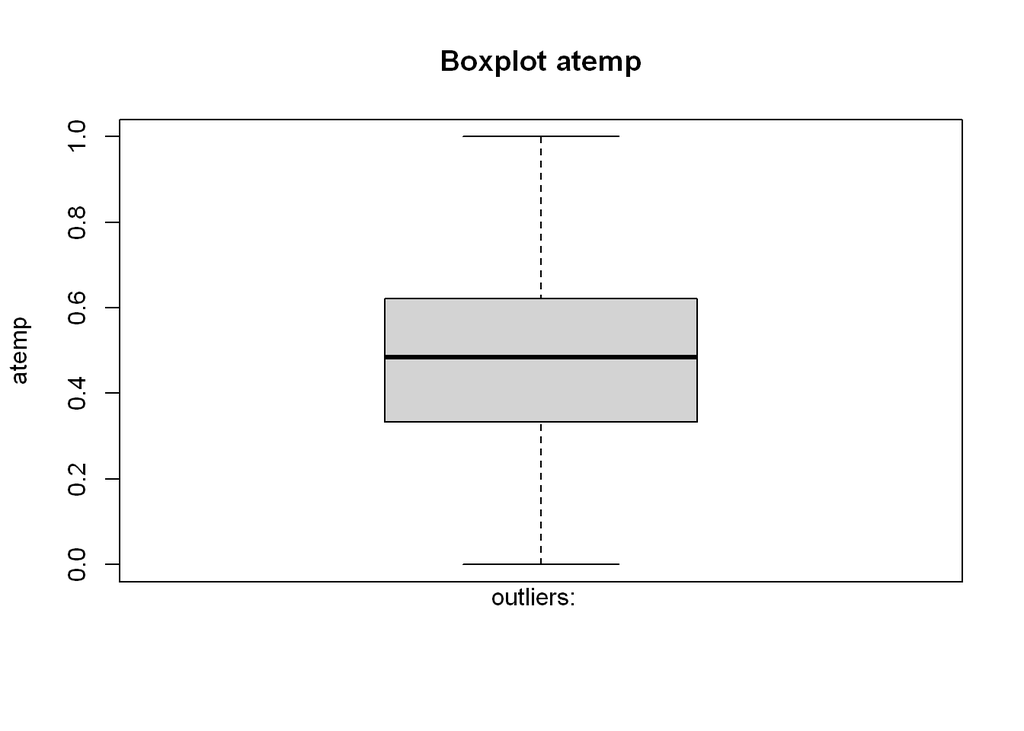

```r
# Diagrama
boxplot(hour$atemp, ylab="atemp", main="Boxplot atemp")

mtext(text = paste("outliers: ", paste(hour.atemp.outliers, collapse = ", ")), side = 1)
```

Verificou-se que não existem outliers presentes no gráfico.

## **4.1. atemp**

### Classificação da variável

Variável quantitativa contínua, e é tratada como quantitativa contínua normal, visto que, tem grande variedade de variaveis distintas.

### Medidas de Tendência Central

#### Moda

```r
hour.day.atemp.moda <- moda(hour.day$atemp)
hour.day.atemp.moda
```

```
## [1] 0.6212
```

#### Média

```r
hour.day.atemp.media <- mean(hour.day$atemp)
hour.day.atemp.media
```

```
## [1] 0.4981943
```

#### Mediana

```r
hour.day.atemp.mediana <- median(hour.day$atemp)
hour.day.atemp.mediana
```

```
## [1] 0.5
```

#### Quartil

```r
hour.day.atemp.quantile <- quantile(hour.day$atemp)
hour.day.atemp.quantile
```

```
##     0%    25%    50%    75%   100%
## 0.0000 0.3485 0.5000 0.6515 1.0000
```

### Medidas de Dispersão Central

#### Variância

```r
hour.day.atemp.variancia <- var(hour.day$atemp)
hour.day.atemp.variancia
```

```
## [1] 0.03187527
```

#### Desvio Padrão

```r
hour.day.atemp.desvio_padrao <- sd(hour.day$atemp)
hour.day.atemp.desvio_padrao
```

```
## [1] 0.1785365
```

#### Coeficiente de Variação

```r
hour.day.atemp.coeficiente_variacao <- coeficiente_variacao(hour.day$atemp)
hour.day.atemp.coeficiente_variacao
```

```
## [1] 35.83671
```

### Valores Extremos

#### Máximo

```r
hour.day.atemp.maxima <- max(hour.day$atemp)
hour.day.atemp.maxima
```

```
## [1] 1
```

#### Mínimo

```r
hour.day.atemp.minima <- min(hour.day$atemp)
hour.day.atemp.minima
```

```
## [1] 0
```

### Medidas de Assimetria

```r
hour.day.atemp.assimetria <- assimetria(hour.day$atemp)
hour.day.atemp.assimetria
```

```
## [1] -0.1370249
```

De acordo com o resultado, é assimétrica negativa (ou enviesada para a esquerda).

### Medidas de Curtose ou Achatamento

```r
hour.day.atemp.achatamento <- achatamento(hour.day$atemp)
hour.day.atemp.achatamento
```

```
## [1] -0.8923441
```

Curva platicúrtica, achatada, o que significa que os valores estão pouco concentrados em torno da média e, consequentemente, existe uma variação elevada.

### Histograma

```r
# formula de sturges
cat("Número de classes\n")
```

```
## Número de classes
```

```r
hour.day.atemp.sturges.nclass <- sturges(hour.day$atemp)
hour.day.atemp.sturges.nclass
```

```
## [1] 14
```

```r
# amplitude da classe
cat("\nAmplitude da classe\n")
```

```
##
## Amplitude da classe
```

```r
hour.day.atemp.sturges.amplitude <- amplitude(hour.day$atemp)
hour.day.atemp.sturges.amplitude
```

```
## [1] 0.07142857
```

```r
# tabela de frequencias
cat("\nClasses\n")
```

```
##
## Classes
```

```r
hour.day.atemp.sturges.breaks <- seq(hour.day.atemp.minima, hour.day.atemp.maxima, hour.day.atemp.sturges.amplitude)
hour.day.atemp.sturges.breaks
```

```
##  [1] 0.00000000 0.07142857 0.14285714 0.21428571 0.28571429 0.35714286
##  [7] 0.42857143 0.50000000 0.57142857 0.64285714 0.71428571 0.78571429
## [13] 0.85714286 0.92857143 1.00000000
```

```r
cat("\nTabela de frequências\n")
```

```
##
## Tabela de frequências
```

```r
table(cut(hour.day$atemp, breaks=hour.day.atemp.sturges.breaks))
```

```
##
##     (0,0.0714] (0.0714,0.143]  (0.143,0.214]  (0.214,0.286]  (0.286,0.357]
##              6            118            424            672           1120
##  (0.357,0.429]    (0.429,0.5]    (0.5,0.571]  (0.571,0.643]  (0.643,0.714]
##            918           1145            799           1344           1333
##  (0.714,0.786]  (0.786,0.857]  (0.857,0.929]      (0.929,1]
##            503            294             57              4
```

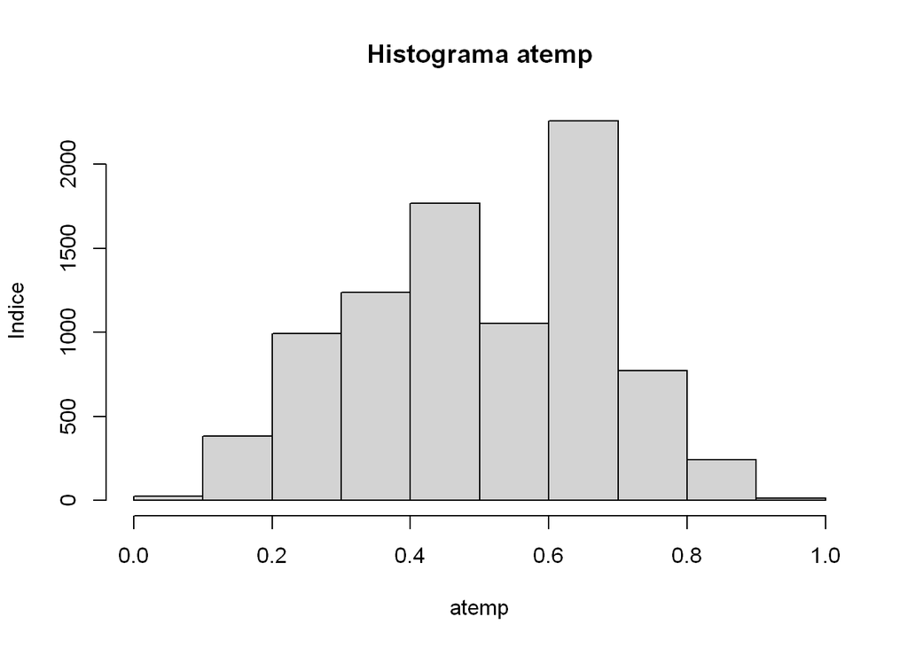

```r
# histograma
hist(hour.day$atemp, main="Histograma atemp", xlab="atemp",  ylab="Indice", nclass=hour.day.atemp.sturges.nclass)
```

### Diagrama de Extremos e Quartis

```r
# Outliers
cat("\nOutliers\n")
```

```
##
## Outliers
```

```r
hour.day.atemp.outliers <- boxplot.stats(hour.day$atemp)$out
hour.day.atemp.outliers
```

```
## numeric(0)
```

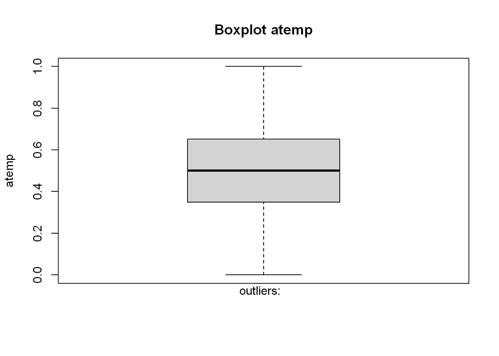

```r
# Diagrama
boxplot(hour.day$atemp, ylab="atemp", main="Boxplot atemp")
mtext(text = paste("outliers: ", paste(hour.day.atemp.outliers, collapse = ", ")), side = 1)
```

Verificou-se que não existem outliers presentes no gráfico.

## **4.2. atemp**

### Classificacao da variavel

Variavel quantitativa continua, e e tratada como quantitativa continua normal, visto que, tem grande variedade de variaveis distintas.

### Medidas de Tendência Central

#### Moda

```r
hour.night.atemp.moda <- moda(hour.night$atemp)
hour.night.atemp.moda
```

```
## [1] 0.6212
```

#### Média

```r
hour.night.atemp.media <- mean(hour.night$atemp)
hour.night.atemp.media
```

```
## [1] 0.4531042
```

#### Mediana

```r
hour.night.atemp.mediana <- median(hour.night$atemp)
hour.night.atemp.mediana
```

```
## [1] 0.4545
```

#### Quartil

```r
hour.night.atemp.quantile <- quantile(hour.night$atemp)
hour.night.atemp.quantile
```

```
##     0%    25%    50%    75%   100%
## 0.0000 0.3182 0.4545 0.5909 0.9242
```

### Medidas de Dispersao Central

#### Variância

```r
hour.night.atemp.variancia <- var(hour.night$atemp)
hour.night.atemp.variancia
```

```
## [1] 0.02614449
```

#### Desvio Padrão

```r
hour.night.atemp.desvio_padrao <- sd(hour.night$atemp)
hour.night.atemp.desvio_padrao
```

```
## [1] 0.1616926
```

#### Coeficiente de Variação

```r
hour.night.atemp.coeficiente_variacao <- coeficiente_variacao(hour.night$atemp)
hour.night.atemp.coeficiente_variacao
```

```
## [1] 35.68552
```

### Valores Extremos

#### Máximo

```r
hour.night.atemp.maxima <- max(hour.night$atemp)
hour.night.atemp.maxima
```

```
## [1] 0.9242
```

#### Mínimo

```r
hour.night.atemp.minima <- min(hour.night$atemp)
hour.night.atemp.minima
```

```
## [1] 0
```

### Medidas de Assimetria

```r
hour.night.atemp.assimetria <- assimetria(hour.night$atemp)
hour.night.atemp.assimetria
```

```
## [1] -0.1239053
```

De acordo com o resultado, é assimétrica negativa (ou enviesada para a esquerda).

### Medidas de Curtose ou Achatamento

```r
hour.night.atemp.achatamento <- achatamento(hour.night$atemp)
hour.night.atemp.achatamento
```

```
## [1] -0.8666668
```

Curva platicúrtica, achatada, o que significa que os valores estao pouco concentrados em torno da média e, consequentemente, existe uma variacao elevada.

### Histograma

```r
# formula de sturges
cat("Número de classes\n")
```

```
## Número de classes
```

```r
hour.night.atemp.sturges.nclass <- sturges(hour.night$atemp)
hour.night.atemp.sturges.nclass
```

```
## [1] 14
```

```r
# amplitude da classe
cat("\nAmplitude da classe\n")
```

```
##
## Amplitude da classe
```

```r
hour.night.atemp.sturges.amplitude <- amplitude(hour.night$atemp)
hour.night.atemp.sturges.amplitude
```

```
## [1] 0.06601429
```

```r
# tabela de frequencias
cat("\nClasses\n")
```

```
##
## Classes
```

```r
hour.night.atemp.sturges.breaks <- seq(hour.night.atemp.minima, hour.night.atemp.maxima, hour.night.atemp.sturges.amplitude)
hour.night.atemp.sturges.breaks
```

```
##  [1] 0.00000000 0.06601429 0.13202857 0.19804286 0.26405714 0.33007143
##  [7] 0.39608571 0.46210000 0.52811429 0.59412857 0.66014286 0.72615714
## [13] 0.79217143 0.85818571 0.92420000
```

```r
cat("\nTabela de frequências\n")
```

```
##
## Tabela de frequências
```

```r
table(cut(hour.night$atemp, breaks=hour.night.atemp.sturges.breaks))
```

```
##
##     (0,0.066] (0.066,0.132] (0.132,0.198] (0.198,0.264]  (0.264,0.33]
##            29            86           344           872           986
##  (0.33,0.396] (0.396,0.462] (0.462,0.528] (0.528,0.594]  (0.594,0.66]
##           883          1138          1056          1247          1114
##  (0.66,0.726] (0.726,0.792] (0.792,0.858] (0.858,0.924]
##           664           183            31             7
```

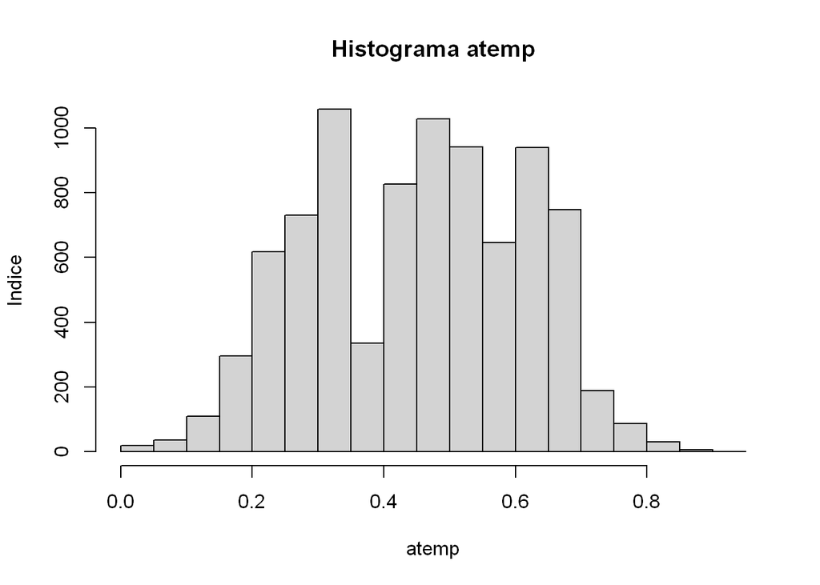

```r
# histograma
hist(hour.night$atemp, main="Histograma atemp", xlab="atemp",  ylab="Indice", nclass=hour.night.atemp.sturges.nclass)
```

### Diagrama de Extremos e Quartis

```r
# Outliers
cat("\nOutliers\n")
```

```
##
## Outliers
```

```r
hour.night.atemp.outliers <- boxplot.stats(hour.night$atemp)$out
hour.night.atemp.outliers
```

```
## numeric(0)
```

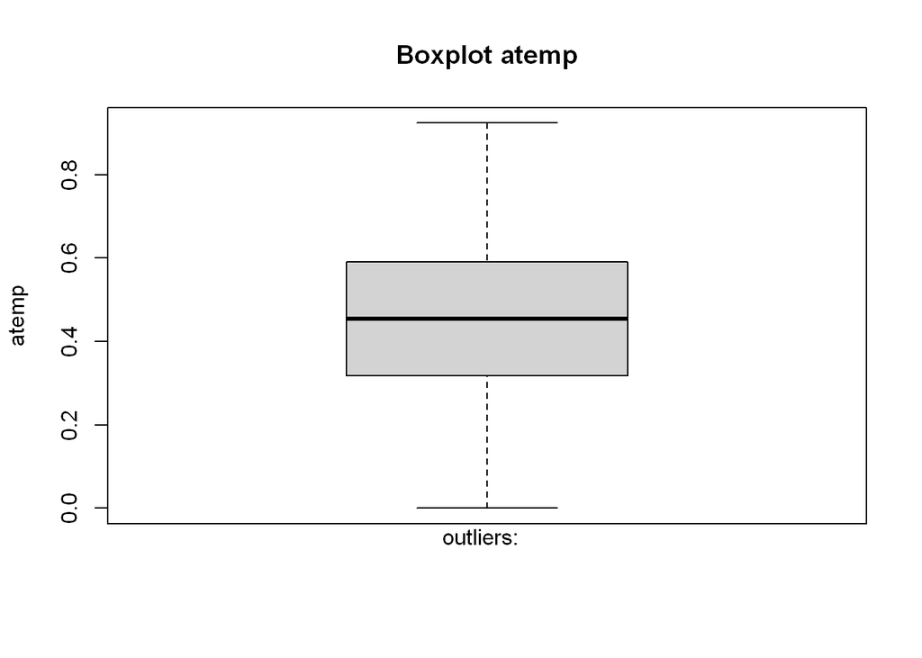

```r
# Diagrama
boxplot(hour.night$atemp, ylab="atemp", main="Boxplot atemp")

mtext(text = paste("outliers: ", paste(hour.night.atemp.outliers, collapse = ", ")), side = 1)
```

Verificou-se que não existem outliers presentes no gráfico.

## **5.. hum**

### Classificação da variável

Variável quantitativa contínua, e é tratada como quantitativa contínua normal, visto que, não tem grande variedade de variaveis distintas.

### Medidas de Tendência Central

#### Moda

```r
hour.hum.moda <- moda(hour$hum)
hour.hum.moda
```

```
## [1] 0.88
```

#### Média

```r
hour.hum.media <- mean(hour$hum)
hour.hum.media
```

```
## [1] 0.6272288
```

#### Mediana

```r
hour.hum.mediana <- median(hour$hum)
hour.hum.mediana
```

```
## [1] 0.63
```

#### Quartil

```r
hour.hum.quantile <- quantile(hour$hum)
hour.hum.quantile
```

```
##   0%  25%  50%  75% 100%
## 0.00 0.48 0.63 0.78 1.00
```

### Medidas de Dispersão Central

#### Variância

```r
hour.hum.variancia <- var(hour$hum)
hour.hum.variancia
```

```
## [1] 0.03722192
```

#### Desvio Padrão

```r
hour.hum.desvio_padrao <- sd(hour$hum)
hour.hum.desvio_padrao
```

```
## [1] 0.1929298
```

#### Coeficiente de Variação

```r
hour.hum.coeficiente_variacao <- coeficiente_variacao(hour$hum)
hour.hum.coeficiente_variacao
```

```
## [1] 30.75908
```

### Valores Extremos

#### Máximo

```r
hour.hum.maxima <- max(hour$hum)
hour.hum.maxima
```

```
## [1] 1
```

#### Mínimo

```r
hour.hum.minima <- min(hour$hum)
hour.hum.minima
```

```
## [1] 0
```

### Medidas de Assimetria

```r
hour.hum.assimetria <- assimetria(hour$hum)
hour.hum.assimetria
```

```
## [1] -0.1112679
```

De acordo com o resultado, é assimétrica negativa (ou enviesada para a esquerda).

### Medidas de Curtose ou Achatamento

```r
hour.hum.achatamento <- achatamento(hour$hum)
hour.hum.achatamento
```

```
## [1] -0.8264745
```

Curva platicúrtica, achatada, o que significa que os valores estão pouco concentrados em torno da média e, consequentemente, existe uma variação elevada.

### Histograma

```r
# formula de sturges
cat("Número de classes\n")
```

```
## Número de classes
```

```r
hour.hum.sturges.nclass <- sturges(hour$hum)
hour.hum.sturges.nclass
```

```
## [1] 15
```

```r
# amplitude da classe
cat("\nAmplitude da classe\n")
```

```
##
## Amplitude da classe
```

```r
hour.hum.sturges.amplitude <- amplitude(hour$hum)
hour.hum.sturges.amplitude
```

```
## [1] 0.06666667
```

```r
# tabela de frequencias
cat("\nClasses\n")
```

```
##
## Classes
```

```r
hour.hum.sturges.breaks <- seq(hour.hum.minima, hour.hum.maxima, hour.hum.sturges.amplitude)
hour.hum.sturges.breaks
```

```
##  [1] 0.00000000 0.06666667 0.13333333 0.20000000 0.26666667 0.33333333
##  [7] 0.40000000 0.46666667 0.53333333 0.60000000 0.66666667 0.73333333
## [13] 0.80000000 0.86666667 0.93333333 1.00000000
```

```r
cat("\nTabela de frequências\n")
```

```
##
## Tabela de frequências
```

```r
table(cut(hour$hum, breaks=hour.hum.sturges.breaks))
```

```
##
##     (0,0.0667] (0.0667,0.133]    (0.133,0.2]    (0.2,0.267]  (0.267,0.333]
##              0              4             69            292            766
##    (0.333,0.4]    (0.4,0.467]  (0.467,0.533]    (0.533,0.6]    (0.6,0.667]
##           1326           1603           1921           1977           1818
##  (0.667,0.733]    (0.733,0.8]    (0.8,0.867]  (0.867,0.933]      (0.933,1]
##           1823           1790           1409           1725            834
```

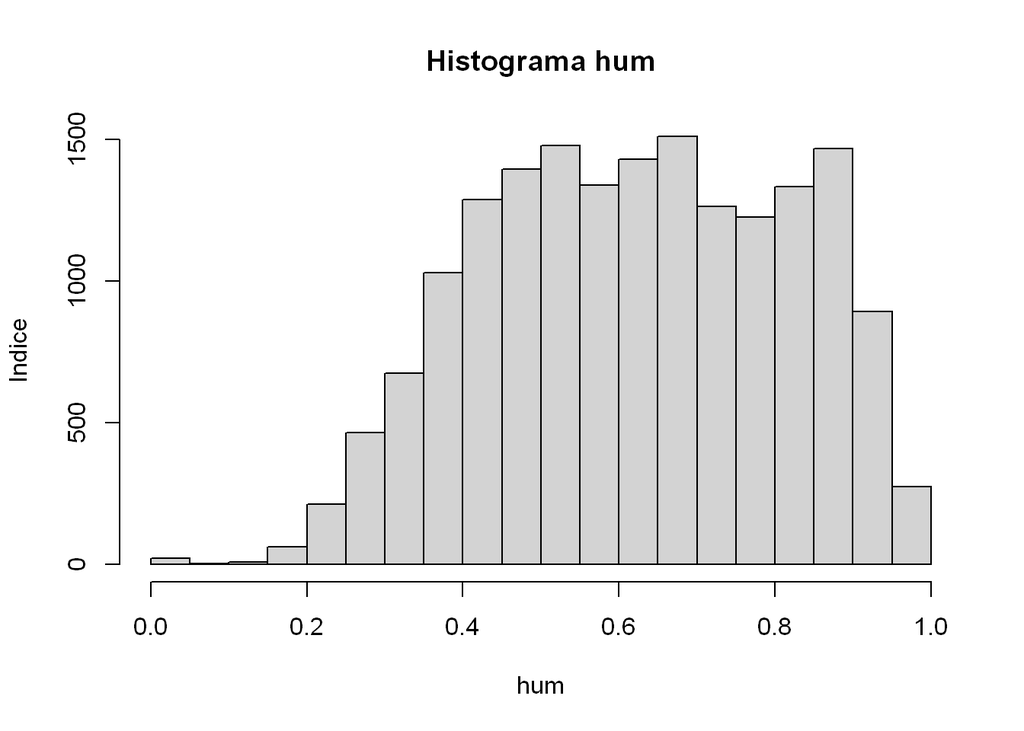

```r
# histograma
hist(hour$hum, main="Histograma hum", xlab="hum",  ylab="Indice", nclass=hour.hum.sturges.nclass)
```

### Diagrama de Extremos e Quartis

```r
# Outliers
cat("\nOutliers\n")
```

```
##
## Outliers
```

```r
hour.hum.outliers <- boxplot.stats(hour$hum)$out
hour.hum.outliers
```

```
##  [1] 0 0 0 0 0 0 0 0 0 0 0 0 0 0 0 0 0 0 0 0 0 0
```

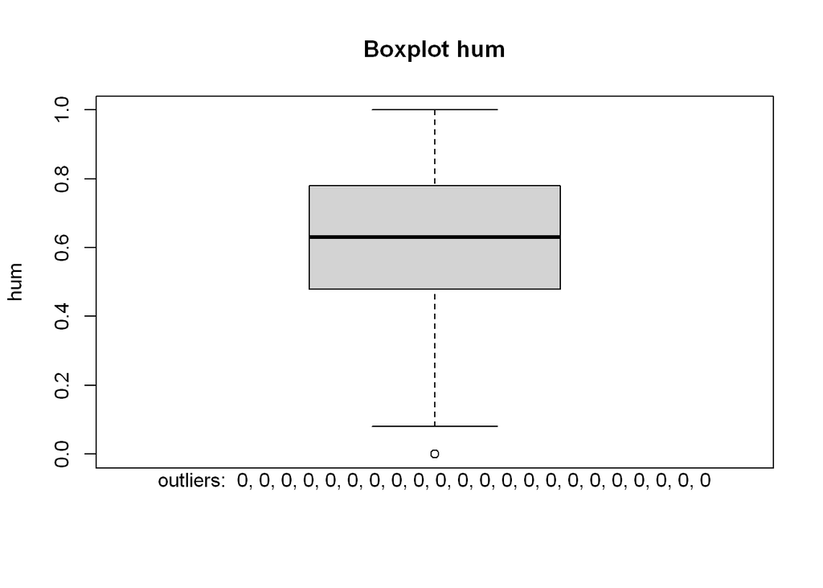

```r
# Diagrama
boxplot(hour$hum, ylab="hum", main="Boxplot hum")

mtext(text = paste("outliers: ", paste(hour.hum.outliers, collapse = ", ")), side = 1)
```

Verificou-se que existem outliers presentes no gráfico no ponto 0.

## **5.1. hum**

### Classificação da variável

Variável quantitativa contínua, e é tratada como quantitativa contínua normal, visto que, não tem grande variedade de variaveis distintas.

### Medidas de Tendência Central

#### Moda

```r
hour.day.hum.moda <- moda(hour.day$hum)
hour.day.hum.moda
```

```
## [1] 0.46
```

#### Média

```r
hour.day.hum.media <- mean(hour.day$hum)
hour.day.hum.media
```

```
## [1] 0.572013
```

#### Mediana

```r
hour.day.hum.mediana <- median(hour.day$hum)
hour.day.hum.mediana
```

```
## [1] 0.55
```

#### Quartil

```r
hour.day.hum.quantile <- quantile(hour.day$hum)
hour.day.hum.quantile
```

```
##   0%  25%  50%  75% 100%
## 0.00 0.42 0.55 0.72 1.00
```

### Medidas de Dispersão Central

#### Variância

```r
hour.day.hum.variancia <- var(hour.day$hum)
hour.day.hum.variancia
```

```
## [1] 0.03764531
```

#### Desvio Padrão

```r
hour.day.hum.desvio_padrao <- sd(hour.day$hum)
hour.day.hum.desvio_padrao
```

```
## [1] 0.194024
```

#### Coeficiente de Variação

```r
hour.day.hum.coeficiente_variacao <- coeficiente_variacao(hour.day$hum)
hour.day.hum.coeficiente_variacao
```

```
## [1] 33.91951
```

### Valores Extremos

#### Máximo

```r
hour.day.hum.maxima <- max(hour.day$hum)
hour.day.hum.maxima
```

```
## [1] 1
```

#### Mínimo

```r
hour.day.hum.minima <- min(hour.day$hum)
hour.day.hum.minima
```

```
## [1] 0
```

### Medidas de Assimetria

```r
hour.day.hum.assimetria <- assimetria(hour.day$hum)
hour.day.hum.assimetria
```

```
## [1] 0.2254248
```

### Medidas de Curtose ou Achatamento

```r
hour.day.hum.achatamento <- achatamento(hour.day$hum)
hour.day.hum.achatamento
```

```
## [1] -0.7835361
```

Curva platicúrtica, achatada, o que significa que os valores estão pouco concentrados em torno da média e, consequentemente, existe uma variação elevada.

### Histograma

```r
# formula de sturges
cat("Número de classes\n")
```

```
## Número de classes
```

```r
hour.day.hum.sturges.nclass <- sturges(hour.day$hum)
hour.day.hum.sturges.nclass
```

```
## [1] 14
```

```r
# amplitude da classe
cat("\nAmplitude da classe\n")
```

```
##
## Amplitude da classe
```

```r
hour.day.hum.sturges.amplitude <- amplitude(hour.day$hum)
hour.day.hum.sturges.amplitude
```

```
## [1] 0.07142857
```

```r
# tabela de frequencias
cat("\nClasses\n")
```

```
##
## Classes
```

```r
hour.day.hum.sturges.breaks <- seq(hour.day.hum.minima, hour.day.hum.maxima, hour.day.hum.sturges.amplitude)
hour.day.hum.sturges.breaks
```

```
##  [1] 0.00000000 0.07142857 0.14285714 0.21428571 0.28571429 0.35714286
##  [7] 0.42857143 0.50000000 0.57142857 0.64285714 0.71428571 0.78571429
## [13] 0.85714286 0.92857143 1.00000000
```

```r
cat("\nTabela de frequências\n")
```

```
##
## Tabela de frequências
```

```r
table(cut(hour.day$hum, breaks=hour.day.hum.sturges.breaks))
```

```
##
##     (0,0.0714] (0.0714,0.143]  (0.143,0.214]  (0.214,0.286]  (0.286,0.357]
##              0              0             75            348            707
##  (0.357,0.429]    (0.429,0.5]    (0.5,0.571]  (0.571,0.643]  (0.643,0.714]
##           1159           1339           1102            887            861
##  (0.714,0.786]  (0.786,0.857]  (0.857,0.929]      (0.929,1]
##            748            568            509            423
```

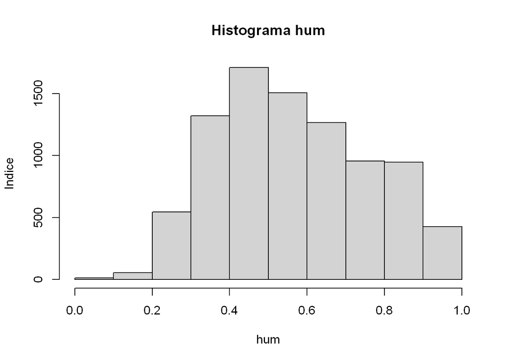

```r
# histograma
hist(hour.day$hum, main="Histograma hum", xlab="hum",  ylab="Indice", nclass=hour.day.hum.sturges.nclass)
```

A partir do histograma, pode-se observar que o valor do índice aumenta no intervalo 0.429 a 0.5 e diminui no intervalo 0.5 a 1, tendo um comportamento crescente e decrescente até atingir o maior índice no intervalo de 0.429 a 0.5.

### Diagrama de Extremos e Quartis

```r
# Outliers
cat("\nOutliers\n")
```

```
##
## Outliers
```

```r
hour.day.hum.outliers <- boxplot.stats(hour.day$hum)$out
hour.day.hum.outliers
```

```
## numeric(0)
```

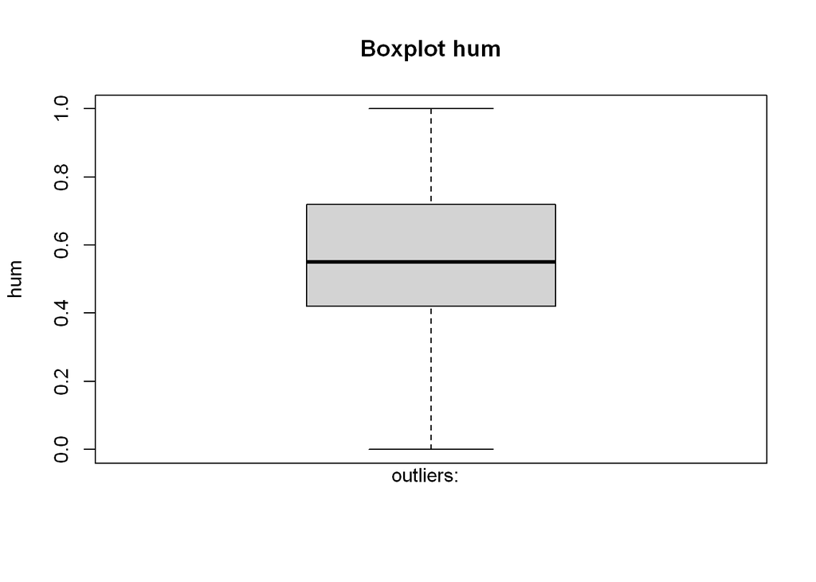

```r
# Diagrama
boxplot(hour.day$hum, ylab="hum", main="Boxplot hum")
mtext(text = paste("outliers: ", paste(hour.day.hum.outliers, collapse = ", ")), side = 1)
```

Verificou-se que não existem outliers presentes no gráfico.

## **5.2. hum**

### Classificação da Variável

Variável quantitativa contínua, e é tratada como quantitativa contínua normal, visto que, não tem grande variedade de variaveis distintas.

### Medidas de Tendência Central

#### Moda

```r
hour.night.hum.moda <- moda(hour.night$hum)
hour.night.hum.moda
```

```
## [1] 0.88
```

#### média

```r
hour.night.hum.media <- mean(hour.night$hum)
hour.night.hum.media
```

```
## [1] 0.6830645
```

#### Mediana

```r
hour.night.hum.mediana <- median(hour.night$hum)
hour.night.hum.mediana
```

```
## [1] 0.7
```

#### Quartil

```r
hour.night.hum.quantile <- quantile(hour.night$hum)
hour.night.hum.quantile
```

```
##   0%  25%  50%  75% 100%
## 0.00 0.56 0.70 0.83 1.00
```

### Medidas de Dispersão Central

#### Variância

```r
hour.night.hum.variancia <- var(hour.night$hum)
hour.night.hum.variancia
```

```
## [1] 0.03059674
```

#### Desvio Padrão

```r
hour.night.hum.desvio_padrao <- sd(hour.night$hum)
hour.night.hum.desvio_padrao
```

```
## [1] 0.1749192
```

#### Coeficiente de variação

```r
hour.night.hum.coeficiente_variacao <- coeficiente_variacao(hour.night$hum)
hour.night.hum.coeficiente_variacao
```

```
## [1] 25.60801
```

### Valores Extremos

#### Máximo

```r
hour.night.hum.maxima <- max(hour.night$hum)
hour.night.hum.maxima
```

```
## [1] 1
```

#### Mínimo

```r
hour.night.hum.minima <- min(hour.night$hum)
hour.night.hum.minima
```

```
## [1] 0
```

### Medidas de Assimetria

```r
hour.night.hum.assimetria <- assimetria(hour.night$hum)
hour.night.hum.assimetria
```

```
## [1] -0.3915097
```

De acordo com o resultado, é assimétrica negativa (ou enviesada para a esquerda).

### Medidas de Curtose ou Achatamento

```r
hour.night.hum.achatamento <- achatamento(hour.night$hum)
hour.night.hum.achatamento
```

```
## [1] -0.4062143
```

Curva platicúrtica, achatada, o que significa que os valores estão pouco concentrados em torno da média e, consequentemente, existe uma variação elevada.

### Histograma

```r
# formula de sturges
cat("Número de classes\n")
```

```
## Número de classes
```

```r
hour.night.hum.sturges.nclass <- sturges(hour.night$hum)
hour.night.hum.sturges.nclass
```

```
## [1] 14
```

```r
# amplitude da classe
cat("\nAmplitude da classe\n")
```

```
##
## Amplitude da classe
```

```r
hour.night.hum.sturges.amplitude <- amplitude(hour.night$hum)
hour.night.hum.sturges.amplitude
```

```
## [1] 0.07142857
```

```r
# tabela de frequencias
cat("\nClasses\n")
```

```
##
## Classes
```

```r
hour.night.hum.sturges.breaks <- seq(hour.night.hum.minima, hour.night.hum.maxima, hour.night.hum.sturges.amplitude)
hour.night.hum.sturges.breaks
```

```
##  [1] 0.00000000 0.07142857 0.14285714 0.21428571 0.28571429 0.35714286
##  [7] 0.42857143 0.50000000 0.57142857 0.64285714 0.71428571 0.78571429
## [13] 0.85714286 0.92857143 1.00000000
```

```r
cat("\nTabela de frequências\n")
```

```
##
## Tabela de frequências
```

```r
table(cut(hour.night$hum, breaks=hour.night.hum.sturges.breaks))
```

```
##
##     (0,0.0714] (0.0714,0.143]  (0.143,0.214]  (0.214,0.286]  (0.286,0.357]
##              0              6             18             86            187
##  (0.357,0.429]    (0.429,0.5]    (0.5,0.571]  (0.571,0.643]  (0.643,0.714]
##            396            819            919            953           1229
##  (0.714,0.786]  (0.786,0.857]  (0.857,0.929]      (0.929,1]
##           1205           1110            961            742
```

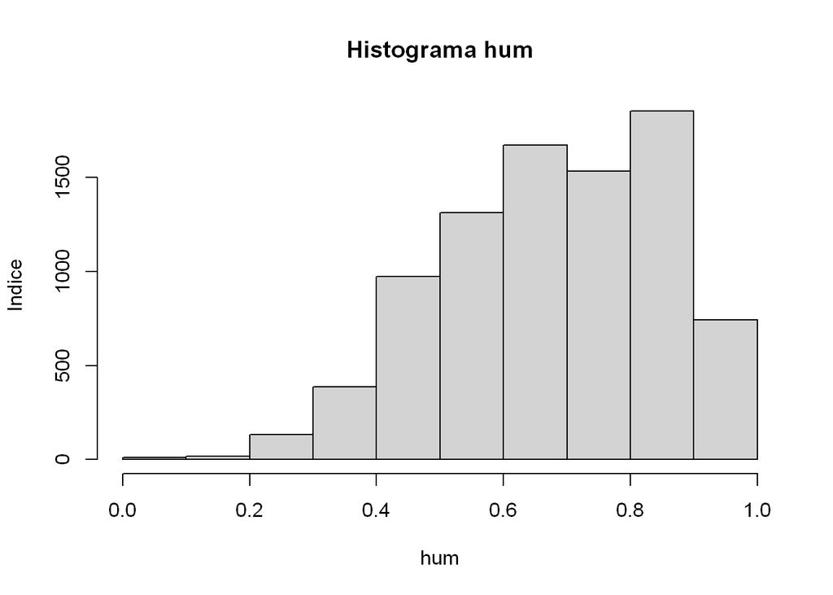

```r
# histograma
hist(hour.night$hum, main="Histograma hum", xlab="hum",  ylab="Indice", nclass=hour.night.hum.sturges.nclass)
```

### Diagrama de Extremos e Quartis

```r
# Outliers
cat("\nOutliers\n")
```

```
##
## Outliers
```

```r
hour.night.hum.outliers <- boxplot.stats(hour.night$hum)$out
hour.night.hum.outliers
```

```
##  [1] 0.10 0.08 0.12 0.14 0.13 0.14 0.15 0.15 0.00 0.00 0.00 0.00 0.00 0.00 0.00
## [16] 0.00 0.00 0.00
```

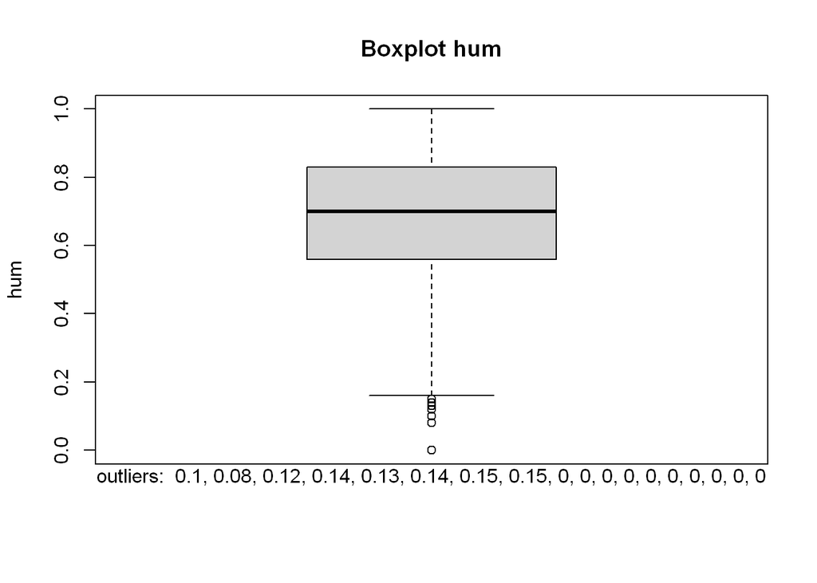

```r
# Diagrama
boxplot(hour.night$hum, ylab="hum", main="Boxplot hum")

mtext(text = paste("outliers: ", paste(hour.night.hum.outliers, collapse = ", ")), side = 1)
```

Verificou-se que existem outliers presentes no gráfico no ponto 0 e perto dele.